# 🥗 AI-Powered Personalized Nutrition Recommendation System

### DSA 502 — Final Project

Combining Machine Learning, Recommendation Systems, and AI/RAG for Personalized Nutrition Intelligence

Developed by: **Abu Hanif**

## Project Overview

Nutrition and health management have become increasingly important in modern life. However, many people still struggle to understand:

- How many calories they burn during exercise
- Which foods match their calorie needs
- How to choose healthier foods
- How protein, fat, and nutrition quality affect health

This project builds an AI-powered personalized nutrition recommendation system that combines:

- Machine Learning
- Food Recommendation Systems
- Nutrition Analytics
- Artificial Intelligence (RAG + Llama 3.2)

The system predicts calories burned using exercise and body information, then recommends personalized foods based on nutrition quality and calorie targets.

## Problem Statement

Traditional diet systems often provide generic recommendations instead of personalized nutrition guidance.

This project solves this problem by building an intelligent system that combines exercise data, machine learning, food nutrition data, and AI-powered recommendations.

## ❓ Research Questions

1. Can machine learning accurately predict calories burned?
2. Which machine learning model performs best for calorie prediction?
3. Can nutrition data be used to generate personalized food recommendations?
4. How can protein, fat, and nutrition density improve recommendation quality?
5. Can AI and RAG improve explanation and interaction in nutrition systems?
6. Can a local LLM assistant answer personalized nutrition questions effectively?

## 🎯 Project Objectives

- Predict calories burned using exercise and body data
- Compare multiple machine learning models
- Create personalized food recommendation logic
- Analyze nutrition quality using engineered features
- Build an AI-powered nutrition assistant
- Use RAG and vector databases for intelligent retrieval
- Create a professional end-to-end AI nutrition system

## 📂 Datasets Used

| Dataset | Purpose |
| --- | --- |
| Exercise Dataset | User exercise and body information |
| Calories Dataset | Target calorie values |
| Food Nutrition Dataset | Nutritional values of foods |
| Recipes Dataset | Cuisine and recipe analysis |

## ⚙️ Project Workflow

Data Loading → Data Cleaning → EDA → Feature Engineering → Machine Learning → Recommendation System → AI/RAG Integration → Interactive Nutrition Assistant

## Starting the Project

Now we begin the technical implementation of the project.

In the next section, we will:

- Load all datasets
- Merge exercise and calorie data
- Combine multiple food nutrition files
- Prepare recipe data
- Preview dataset structures and dimensions

## PART 1 — IMPORT LIBRARIES AND PROJECT SETUP

# 📚 Part 1 — Import Libraries and Project Setup

Before starting the project, we first import all required Python libraries and configure the notebook environment.

This setup section prepares the tools needed for:

- Data analysis and manipulation
- Data visualization
- Machine learning
- Recommendation systems
- AI and RAG integration

We also configure colorful visualization themes and notebook styling for cleaner and more professional outputs throughout the project.

```python
import pandas as pd
import numpy as np

import matplotlib.pyplot as plt
import seaborn as sns

from pathlib import Path
import warnings
warnings.filterwarnings("ignore")

# Display settings
pd.set_option("display.max_columns", None)
pd.set_option("display.max_rows", 100)

# Plot style
sns.set_theme(style="whitegrid")
plt.rcParams["figure.figsize"] = (10, 6)
plt.rcParams["axes.titlesize"] = 16
plt.rcParams["axes.labelsize"] = 12
plt.rcParams["font.size"] = 11

print("✅ Libraries loaded successfully.")
```

```
✅ Libraries loaded successfully.
```

# 📂 Part 2 — Load Datasets

In this section, we load all datasets required for the personalized nutrition recommendation system.

The project combines multiple datasets including:

- Exercise and body information
- Calories burned data
- Food nutrition datasets
- Recipe and cuisine datasets

We merge related datasets, combine nutrition files, and preview the structure of each dataset before moving into data cleaning and analysis.

This step creates the main foundation for machine learning, recommendation systems, and AI-powered nutrition analysis.

```python
# Folder path
path = r"C:\University Course\DSA 502\Hanif_DSA502_Final Project_AI-Powered Personalized Nutrition Recommendation System"

# -----------------------------------------
# Load exercise and calories datasets
# -----------------------------------------
exercise = pd.read_excel(path + r"\exercise.xlsx")
calories = pd.read_excel(path + r"\calories.xlsx")

# Merge datasets
df = pd.merge(exercise, calories, on="User_ID")

# -----------------------------------------
# Load food nutrition datasets
# -----------------------------------------
food1 = pd.read_excel(path + r"\FOOD-DATA-GROUP1.xlsx")
food2 = pd.read_excel(path + r"\FOOD-DATA-GROUP2.xlsx")
food3 = pd.read_excel(path + r"\FOOD-DATA-GROUP3.xlsx")
food4 = pd.read_excel(path + r"\FOOD-DATA-GROUP4.xlsx")
food5 = pd.read_excel(path + r"\FOOD-DATA-GROUP5.xlsx")

# Combine food datasets
food_df = pd.concat([food1, food2, food3, food4, food5], ignore_index=True)

# -----------------------------------------
# Load recipes dataset
# -----------------------------------------
recipes_df = pd.read_excel(path + r"\Receipes from around the world.xlsx")

# -----------------------------------------
# Preview datasets
# -----------------------------------------
print("Merged calorie dataset:")
display(df.head())

print("Food nutrition dataset:")
display(food_df.head())

print("Recipes dataset:")
display(recipes_df.head())

# -----------------------------------------
# Dataset shapes
# -----------------------------------------
print("Merged dataset shape:", df.shape)
print("Food dataset shape:", food_df.shape)
print("Recipes dataset shape:", recipes_df.shape)
```

```
Merged calorie dataset:
```

|  | User_ID | Gender | Age | Height | Weight | Duration | Heart_Rate | Body_Temp | Calories |
| --- | --- | --- | --- | --- | --- | --- | --- | --- | --- |
| 0 | 14733363 | male | 68 | 190 | 94 | 29 | 105 | 40.8 | 231 |
| 1 | 14861698 | female | 20 | 166 | 60 | 14 | 94 | 40.3 | 66 |
| 2 | 11179863 | male | 69 | 179 | 79 | 5 | 88 | 38.7 | 26 |
| 3 | 16180408 | female | 34 | 179 | 71 | 13 | 100 | 40.5 | 71 |
| 4 | 17771927 | female | 27 | 154 | 58 | 10 | 81 | 39.8 | 35 |

```
Food nutrition dataset:
```

|  | Unnamed: 0.1 | Unnamed: 0 | food | Caloric Value | Fat | Saturated Fats | Monounsaturated Fats | Polyunsaturated Fats | Carbohydrates | Sugars | Protein | Dietary Fiber | Cholesterol | Sodium | Water | Vitamin A | Vitamin B1 | Vitamin B11 | Vitamin B12 | Vitamin B2 | Vitamin B3 | Vitamin B5 | Vitamin B6 | Vitamin C | Vitamin D | Vitamin E | Vitamin K | Calcium | Copper | … |
| --- | --- | --- | --- | --- | --- | --- | --- | --- | --- | --- | --- | --- | --- | --- | --- | --- | --- | --- | --- | --- | --- | --- | --- | --- | --- | --- | --- | --- | --- | --- |
| 0 | 0 | 0 | cream cheese | 51 | 5.0 | 2.9 | 1.3 | 0.200 | 0.8 | 0.500 | 0.9 | 0.0 | 14.6 | 0.016 | 7.6 | 0.200 | 0.033 | 0.064 | 0.092 | 0.097 | 0.084 | 0.052 | 0.096 | 0.004 | 0.000 | 0.000 | 0.100 | 0.008 | 14.100 | … |
| 1 | 1 | 1 | neufchatel cheese | 215 | 19.4 | 10.9 | 4.9 | 0.800 | 3.1 | 2.700 | 7.8 | 0.0 | 62.9 | 0.300 | 53.6 | 0.200 | 0.099 | 0.079 | 0.090 | 0.100 | 0.200 | 0.500 | 0.078 | 0.000 | 0.000 | 0.300 | 0.045 | 99.500 | 0.034 | … |
| 2 | 2 | 2 | requeijao cremoso light catupiry | 49 | 3.6 | 2.3 | 0.9 | 0.000 | 0.9 | 3.400 | 0.8 | 0.1 | 0.0 | 0.000 | 0.0 | 0.000 | 0.000 | 0.000 | 0.000 | 0.000 | 0.000 | 0.000 | 0.000 | 0.000 | 0.000 | 0.000 | 0.000 | 0.000 | 0.000 | … |
| 3 | 3 | 3 | ricotta cheese | 30 | 2.0 | 1.3 | 0.5 | 0.002 | 1.5 | 0.091 | 1.5 | 0.0 | 9.8 | 0.017 | 14.7 | 0.075 | 0.019 | 0.079 | 0.091 | 0.027 | 0.041 | 0.016 | 0.007 | 0.006 | 0.000 | 0.001 | 0.011 | 0.097 | 41.200 | … |
| 4 | 4 | 4 | cream cheese low fat | 30 | 2.3 | 1.4 | 0.6 | 0.042 | 1.2 | 0.900 | 1.2 | 0.0 | 8.1 | 0.046 | 10.0 | 0.016 | 0.080 | 0.062 | 0.049 | 0.026 | 0.080 | 0.100 | 0.003 | 0.000 | 0.036 | 0.009 | 0.019 | 22.200 | 0.072 | … |

```
Recipes dataset:
```

|  | recipe_name | cuisine | ingredients | cooking_time_minutes | prep_time_minutes | servings | calories_per_serving | dietary_restrictions |
| --- | --- | --- | --- | --- | --- | --- | --- | --- |
| 0 | Spicy Kimchi Fried Rice | Korean | ['Cooked rice', 'Kimchi', 'Gochujang', 'Soy sa... | 25 | 15 | 2.0 | 450.0 | ['vegetarian'] |
| 1 | Classic Margherita Pizza | Italian | ['Pizza dough', 'Tomato sauce', 'Fresh mozzare... | 20 | 30 | 4.0 | 350.0 | ['vegetarian'] |
| 2 | Coconut Chickpea Curry | Indian | ['Chickpeas', 'Coconut milk', 'Onion', 'Ginger... | 35 | 15 | 4.0 | 480.0 | ['vegan', 'vegetarian', 'gluten-free', 'dairy-... |
| 3 | Pad See Ew with Tofu | Thai | ['Wide rice noodles', 'Tofu', 'Chinese broccol... | 20 | 10 | 2.0 | 520.0 | ['vegetarian'] |
| 4 | Beef Bourguignon | French | ['Beef chuck', 'Red wine', 'Bacon', 'Onion', '... | 150 | 30 | 6.0 | 680.0 | ['nan'] |

```
Merged dataset shape: (15000, 9)
Food dataset shape: (2395, 37)
Recipes dataset shape: (161, 8)
```

## ✅ After Part 2: What We Got

Now all datasets are loaded correctly.

The **exercise** and **calories** files were merged into one main dataset using **User_ID**.  
This dataset will be used later to predict calories burned.

The five food nutrition files were combined into one large **food_df**.  
This dataset will be used later to recommend foods based on calories, protein, fat, carbs, fiber, sodium, and nutrition quality.

The recipe dataset was also loaded separately.  
This will support the recipe and AI explanation part of the project.

# 🧪 Part 3 — Data Audit & Quality Check

Before cleaning or modeling, we need to carefully inspect the datasets to ensure the data is reliable, consistent, and ready for analysis.

This section works like a health check for the project data.

- Checking missing values
- Finding duplicate records
- Inspecting data types
- Reviewing dataset structure
- Identifying possible quality issues

Performing a proper data audit is extremely important because machine learning and AI systems depend heavily on clean and trustworthy data.

This step helps us understand potential problems early before moving into data cleaning, feature engineering, and model development.

```python
print("===== MERGED CALORIE DATASET DTYPES =====")
display(df.dtypes)

print("\n===== FOOD NUTRITION DATASET DTYPES =====")
display(food_df.dtypes)

print("\n===== RECIPES DATASET DTYPES =====")
display(recipes_df.dtypes)
```

```
===== MERGED CALORIE DATASET DTYPES =====
```

```
User_ID         int64
Gender         object
Age             int64
Height          int64
Weight          int64
Duration        int64
Heart_Rate      int64
Body_Temp     float64
Calories        int64
dtype: object
```

```
===== FOOD NUTRITION DATASET DTYPES =====
```

```
Unnamed: 0.1              int64
Unnamed: 0                int64
food                     object
Caloric Value             int64
Fat                     float64
Saturated Fats          float64
Monounsaturated Fats    float64
Polyunsaturated Fats    float64
Carbohydrates           float64
Sugars                  float64
Protein                 float64
Dietary Fiber           float64
Cholesterol             float64
Sodium                  float64
Water                   float64
Vitamin A               float64
Vitamin B1              float64
Vitamin B11             float64
Vitamin B12             float64
Vitamin B2              float64
Vitamin B3              float64
Vitamin B5              float64
Vitamin B6              float64
Vitamin C               float64
Vitamin D               float64
Vitamin E               float64
Vitamin K               float64
Calcium                 float64
Copper                  float64
Iron                    float64
Magnesium               float64
Manganese               float64
Phosphorus              float64
Potassium               float64
Selenium                float64
Zinc                    float64
Nutrition Density       float64
dtype: object
```

```
===== RECIPES DATASET DTYPES =====
```

```
recipe_name              object
cuisine                  object
ingredients              object
cooking_time_minutes      int64
prep_time_minutes         int64
servings                float64
calories_per_serving    float64
dietary_restrictions     object
dtype: object
```

# 🟡 Part 3.1 — Missing Value Check

In this section, we inspect all datasets for missing values before starting data cleaning and machine learning.

Missing values are very important because incomplete data can negatively affect analysis, visualizations, recommendation quality, and machine learning performance.

- Missing values can reduce model accuracy
- They can create misleading insights in charts
- They may cause errors during feature engineering
- They can weaken personalized recommendations

By identifying missing values early, we can decide which columns need cleaning, replacement, or further preprocessing before moving into deeper analysis.

This step helps ensure the datasets are reliable and ready for machine learning and AI integration.

```python
print("===== MISSING VALUES =====")

print("\nMerged calorie dataset missing values:")
display(df.isnull().sum())

print("\nFood nutrition dataset missing values:")
display(food_df.isnull().sum())

print("\nRecipes dataset missing values:")
display(recipes_df.isnull().sum())
```

```
===== MISSING VALUES =====

Merged calorie dataset missing values:
```

```
User_ID       0
Gender        0
Age           0
Height        0
Weight        0
Duration      0
Heart_Rate    0
Body_Temp     0
Calories      0
dtype: int64
```

```
Food nutrition dataset missing values:
```

```
Unnamed: 0.1            0
Unnamed: 0              0
food                    0
Caloric Value           0
Fat                     0
Saturated Fats          0
Monounsaturated Fats    0
Polyunsaturated Fats    0
Carbohydrates           0
Sugars                  0
Protein                 0
Dietary Fiber           0
Cholesterol             0
Sodium                  0
Water                   0
Vitamin A               0
Vitamin B1              0
Vitamin B11             0
Vitamin B12             0
Vitamin B2              0
Vitamin B3              0
Vitamin B5              0
Vitamin B6              0
Vitamin C               0
Vitamin D               0
Vitamin E               0
Vitamin K               0
Calcium                 0
Copper                  0
Iron                    0
Magnesium               0
Manganese               0
Phosphorus              0
Potassium               0
Selenium                0
Zinc                    0
Nutrition Density       0
dtype: int64
```

```
Recipes dataset missing values:
```

```
recipe_name             0
cuisine                 0
ingredients             0
cooking_time_minutes    0
prep_time_minutes       0
servings                4
calories_per_serving    5
dietary_restrictions    0
dtype: int64
```

```python
# ============================================================
# MISSING VALUE SUMMARY TABLE
# ============================================================

missing_summary = pd.DataFrame({
    "Dataset": ["Merged Calorie Dataset", "Food Nutrition Dataset", "Recipes Dataset"],
    "Total Missing Values": [
        df.isnull().sum().sum(),
        food_df.isnull().sum().sum(),
        recipes_df.isnull().sum().sum()
    ],
    "Rows": [df.shape[0], food_df.shape[0], recipes_df.shape[0]],
    "Columns": [df.shape[1], food_df.shape[1], recipes_df.shape[1]]
})

missing_summary["Missing Status"] = missing_summary["Total Missing Values"].apply(
    lambda x: "No Missing Values" if x == 0 else "Missing Values Found"
)

display(missing_summary)
```

|  | Dataset | Total Missing Values | Rows | Columns | Missing Status |
| --- | --- | --- | --- | --- | --- |
| 0 | Merged Calorie Dataset | 0 | 15000 | 9 | No Missing Values |
| 1 | Food Nutrition Dataset | 0 | 2395 | 37 | No Missing Values |
| 2 | Recipes Dataset | 9 | 161 | 8 | Missing Values Found |

```
✅ Professional visualization theme loaded.
```

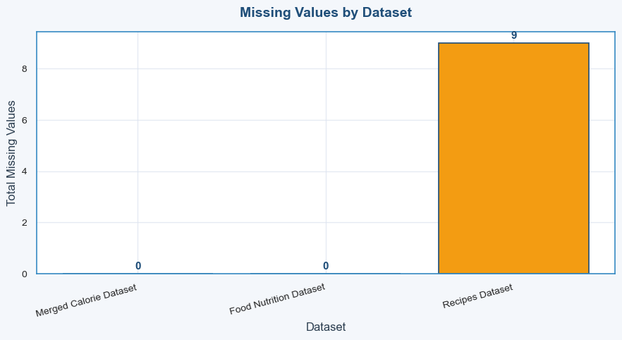

```python
# ============================================================
# GLOBAL VISUALIZATION THEME
# ============================================================

# BEAUTIFUL MISSING VALUE CHART
PRIMARY = "#1f4e79"
ACCENT = "#2e86c1"
GOLD = "#f4b942"
MUTED = "#dde4ef"

sns.set_theme(
    style="whitegrid",
    context="notebook",
    font_scale=1.05
)

plt.rcParams.update({
    "figure.facecolor": "#f4f7fb",
    "axes.facecolor": "#ffffff",
    "axes.edgecolor": ACCENT,
    "axes.linewidth": 1.15,
    "axes.titlesize": 14,
    "axes.titleweight": "bold",
    "axes.titlecolor": PRIMARY,
    "axes.labelcolor": "#2c3e50",
    "axes.labelsize": 12,
    "xtick.labelsize": 10,
    "ytick.labelsize": 10,
    "grid.color": MUTED,
    "grid.alpha": 0.75,
    "legend.frameon": True,
    "legend.facecolor": "white",
    "legend.edgecolor": ACCENT,
})

print("✅ Professional visualization theme loaded.")
plt.figure(figsize=(9, 5))

colors = ["#2ecc71" if v == 0 else "#f39c12" for v in missing_summary["Total Missing Values"]]

bars = plt.bar(
    missing_summary["Dataset"],
    missing_summary["Total Missing Values"],
    color=colors,
    edgecolor=PRIMARY,
    linewidth=1.2
)

plt.title("Missing Values by Dataset", pad=15)
plt.xlabel("Dataset")
plt.ylabel("Total Missing Values")
plt.xticks(rotation=15, ha="right")

# Add value labels
for bar in bars:
    height = bar.get_height()
    plt.text(
        bar.get_x() + bar.get_width()/2,
        height + 0.1,
        f"{int(height)}",
        ha="center",
        va="bottom",
        fontsize=11,
        fontweight="bold",
        color=PRIMARY
    )

plt.tight_layout()
plt.show()
```

## ✅ After Part 3: Data Quality Summary

After checking the datasets, we found that the project data is mostly clean and ready for the next step.

This means the datasets are strong enough to continue into cleaning, feature engineering, EDA, machine learning, recommendation, and AI/RAG work.

# 🧹 Part 4 — Data Cleaning & Preprocessing

Raw datasets are usually not fully ready for analysis and machine learning.

Before building models, recommendation systems, and AI pipelines, we must clean and organize the datasets carefully to improve reliability and consistency.

- Removing unnecessary columns
- Fixing missing values
- Renaming columns into cleaner format
- Standardizing text and categorical data
- Preparing datasets for EDA and modeling

Proper preprocessing is extremely important because clean data leads to better visualizations, stronger machine learning performance, and more accurate personalized recommendations.

This step creates a strong foundation for the remaining stages of the project including feature engineering, recommendation systems, and AI integration.

```python
# ============================================================
# REMOVE UNNECESSARY COLUMNS
# ============================================================

print("Original merged dataset shape:", df.shape)

# Remove User_ID because it is only an identifier
df.drop(columns=["User_ID"], inplace=True)

print("Updated merged dataset shape:", df.shape)
```

```
Original merged dataset shape: (15000, 9)
Updated merged dataset shape: (15000, 8)
```

### 📌 Why We Removed User_ID

The **User_ID** column is only used for identifying users.

It does not help machine learning understand calorie patterns because IDs do not contain meaningful health information.

Removing unnecessary columns helps:

- Reduce noise in the model
- Improve training efficiency
- Keep the dataset clean and focused

```python
# ============================================================
# RENAME COLUMNS
# ============================================================

# Clean column names in merged dataset
df.columns = [col.lower().replace(" ", "_") for col in df.columns]

# Clean food dataset column names
food_df.columns = [col.lower().replace(" ", "_") for col in food_df.columns]

# Clean recipes dataset column names
recipes_df.columns = [col.lower().replace(" ", "_") for col in recipes_df.columns]

print("✅ Column names cleaned successfully.")
```

```
✅ Column names cleaned successfully.
```

```python
# ============================================================
# PREVIEW CLEANED COLUMN NAMES
# ============================================================

print("Merged dataset columns:")
print(df.columns.tolist())

print("\nFood dataset columns:")
print(food_df.columns.tolist())

print("\nRecipes dataset columns:")
print(recipes_df.columns.tolist())
```

```
Merged dataset columns:
['gender', 'age', 'height', 'weight', 'duration', 'heart_rate', 'body_temp', 'calories']

Food dataset columns:
['unnamed:_0.1', 'unnamed:_0', 'food', 'caloric_value', 'fat', 'saturated_fats', 'monounsaturated_fats', 'polyunsaturated_fats', 'carbohydrates', 'sugars', 'protein', 'dietary_fiber', 'cholesterol', 'sodium', 'water', 'vitamin_a', 'vitamin_b1', 'vitamin_b11', 'vitamin_b12', 'vitamin_b2', 'vitamin_b3…

Recipes dataset columns:
['recipe_name', 'cuisine', 'ingredients', 'cooking_time_minutes', 'prep_time_minutes', 'servings', 'calories_per_serving', 'dietary_restrictions']
```

### ✅ Why Clean Column Names?

Column names with spaces or mixed formatting can create problems during:

- Machine learning
- Feature engineering
- Visualization
- Recommendation system building

Now all column names use:

- Lowercase letters
- Underscores instead of spaces
- Cleaner professional format

### 🟠 Fixing Missing Recipe Values

Earlier, we found a small number of missing values in the recipe dataset.

Now we will fix them using the **median** value.

Median is a good choice because it is more stable and less affected by extreme values than the mean.

```python
# ============================================================
# MISSING VALUES BEFORE CLEANING
# ============================================================

print("no. of missing null values (before):")
display(recipes_df.isnull().sum())
```

```
no. of missing null values (before):
```

```
recipe_name             0
cuisine                 0
ingredients             0
cooking_time_minutes    0
prep_time_minutes       0
servings                4
calories_per_serving    5
dietary_restrictions    0
dtype: int64
```

```python
# ============================================================
# FILL MISSING VALUES
# ============================================================

# Fill numeric missing values with median
recipes_df["servings"] = recipes_df["servings"].fillna(
    recipes_df["servings"].median()
)

recipes_df["calories_per_serving"] = recipes_df["calories_per_serving"].fillna(
    recipes_df["calories_per_serving"].median()
)

print("✅ Missing values handled successfully.")
```

```
✅ Missing values handled successfully.
```

```python
# ============================================================
# MISSING VALUES AFTER CLEANING
# ============================================================

print("no. of missing null values (after):")
display(recipes_df.isnull().sum())
```

```
no. of missing null values (after):
```

```
recipe_name             0
cuisine                 0
ingredients             0
cooking_time_minutes    0
prep_time_minutes       0
servings                0
calories_per_serving    0
dietary_restrictions    0
dtype: int64
```

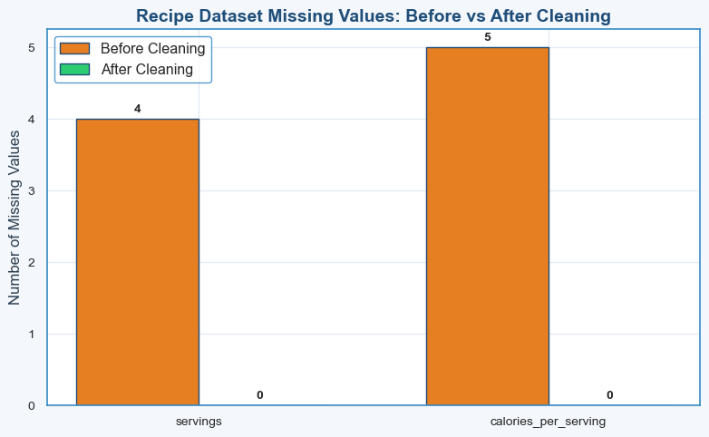

```python
# ============================================================
# BEFORE VS AFTER MISSING VALUES
# ============================================================

before_missing = [4, 5]
after_missing = [0, 0]

labels = ["servings", "calories_per_serving"]

x = np.arange(len(labels))
width = 0.35

plt.figure(figsize=(8,5))

bars1 = plt.bar(
    x - width/2,
    before_missing,
    width,
    label="Before Cleaning",
    color="#e67e22",
    edgecolor=PRIMARY
)

bars2 = plt.bar(
    x + width/2,
    after_missing,
    width,
    label="After Cleaning",
    color="#2ecc71",
    edgecolor=PRIMARY
)

plt.title("Recipe Dataset Missing Values: Before vs After Cleaning")
plt.ylabel("Number of Missing Values")
plt.xticks(x, labels)

# Value labels
for bars in [bars1, bars2]:
    for bar in bars:
        height = bar.get_height()
        plt.text(
            bar.get_x() + bar.get_width()/2,
            height + 0.05,
            f"{int(height)}",
            ha="center",
            va="bottom",
            fontsize=10,
            fontweight="bold"
        )

plt.legend()
plt.tight_layout()
plt.show()
```

## ✅ After Part 4: What We Achieved

The datasets are now cleaner and more professional for analysis and machine learning.

- Removed unnecessary columns
- Standardized all column names
- Fixed missing recipe values
- Prepared datasets for EDA and AI modeling

In simple words, the datasets are now organized, clean, and ready for the next stages: EDA, feature engineering, calorie prediction, recommendation systems, and AI/RAG integration.

# 📊 Part 5 — Exploratory Data Analysis (EDA)

Exploratory Data Analysis (EDA) helps us understand the hidden patterns, trends, and relationships inside the datasets before building machine learning and AI systems.

EDA is one of the most important stages in data science because it allows us to explore the data visually and statistically before making predictions or recommendations.

- Analyzing user age and gender distributions
- Understanding calorie burn patterns
- Exploring workout duration and heart rate behavior
- Identifying healthy and high-protein foods
- Analyzing recipe and cuisine characteristics
- Studying relationships between exercise and calories

These insights help us understand which factors influence calorie prediction and personalized nutrition recommendations.

The findings from EDA also guide feature engineering, machine learning model selection, and AI recommendation strategies later in the project.

### AGE DISTRIBUTION

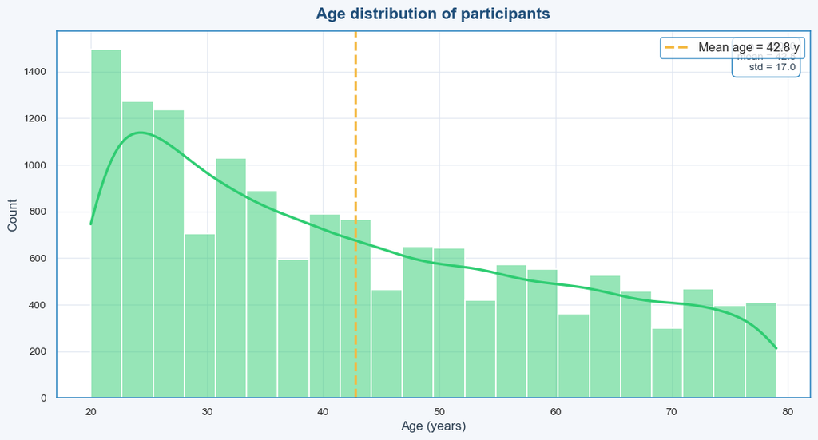

```
count    15000.000000
mean        42.789800
std         16.980264
min         20.000000
25%         28.000000
50%         39.000000
75%         56.000000
max         79.000000
Name: age, dtype: float64
```

```python
fig, ax = plt.subplots(figsize=(11, 6), facecolor="#f4f7fb")

sns.histplot(df["age"], bins=22, color="#2ecc71", edgecolor="white", linewidth=1.2, kde=True,
             line_kws={"color": PRIMARY, "lw": 2.4}, ax=ax)

mu = df["age"].mean()
ax.axvline(mu, color=GOLD, ls="--", lw=2.4, label=f"Mean age = {mu:.1f} y")
ax.legend(loc="upper right", frameon=True)

st = df["age"].describe()
ax.text(
    0.98, 0.97,
    f"n = {int(st['count'])}\nmean = {st['mean']:.1f}\nstd = {st['std']:.1f}",
    transform=ax.transAxes, ha="right", va="top", fontsize=10, color="#2c3e50",
    bbox=dict(boxstyle="round,pad=0.45", facecolor="white", edgecolor=ACCENT, linewidth=1.0),
)

ax.set_title("Age distribution of participants", color=PRIMARY, fontsize=15, pad=12)
ax.set_xlabel("Age (years)")
ax.set_ylabel("Count")
plt.tight_layout()
plt.show()

print(df["age"].describe())
```

### **Age histogram + mean line**

**Key visual:** Bars are frequency of participants by age bucket; gold dashed line marks the dataset mean age.

- Ages span **20–79** with a taller stack in younger brackets (roughly **20–40**).
- The mean marker summarizes central tendency without hiding skew—good for discussing **who the model sees most**.
- Fewer older rows means **higher uncertainty** for that tail unless you collect more data.

**✔ Final insight:** Expect slightly stronger model fit where the histogram is tallest; extrapolate carefully for sparse ages.

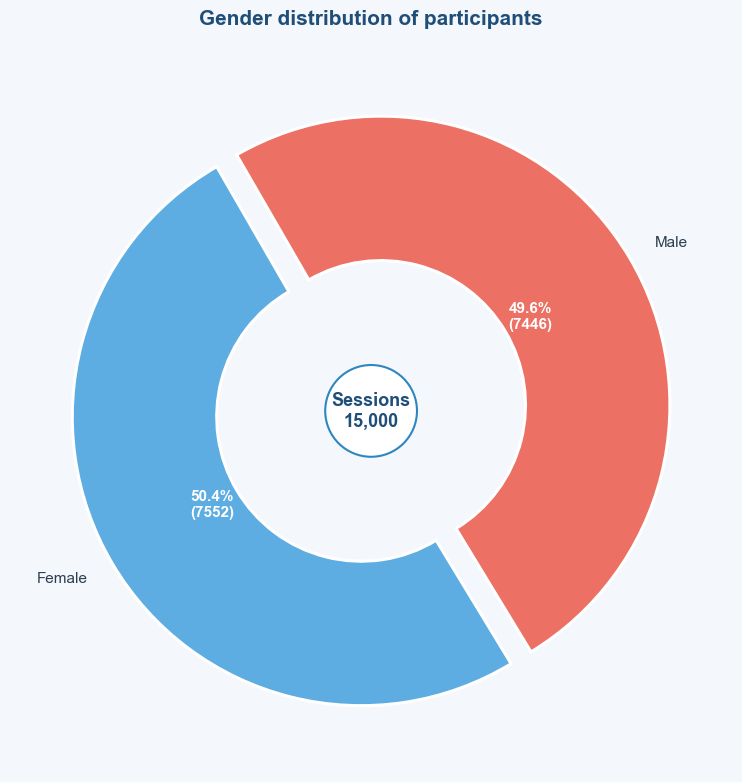

```python
fig, ax = plt.subplots(figsize=(10, 8), facecolor="#f4f7fb")

gender_counts = df["gender"].value_counts()
colors = ["#5DADE2", "#EC7063"]
explode = (0.04, 0.04)

wedges, texts, autotexts = ax.pie(
    gender_counts,
    labels=gender_counts.index.astype(str).str.title(),
    autopct=lambda p: f"{p:.1f}%\n({int(p/100*gender_counts.sum())})",
    colors=colors,
    startangle=120,
    wedgeprops=dict(width=0.5, edgecolor="white", linewidth=2.2),
    explode=explode,
    textprops={"fontsize": 11, "color": "#2c3e50"},
)

for autotext in autotexts:
    autotext.set_fontweight("bold")
    autotext.set_color("white")
    autotext.set_fontsize(11)

centre_txt = f"Sessions\n{len(df):,}"
ax.text(0, 0, centre_txt, ha="center", va="center", fontsize=13, fontweight="bold", color=PRIMARY,
        bbox=dict(boxstyle="circle,pad=0.35", facecolor="white", edgecolor=ACCENT, linewidth=1.5))

ax.set_title("Gender distribution of participants", color=PRIMARY, fontsize=15, pad=18)
plt.tight_layout()
plt.show()
```

### **Gender split (pie chart)**

**Key visual:** Each slice is the share of workout sessions by gender; labels show percent and count.

| Group | Share | Sessions |
| --- | --- | --- |
| **Female** | 50.4% | 7,552 |
| **Male** | 49.6% | 7,446 |

- Near parity supports **fair comparisons** across groups in supervised learning.
- Use this slide when discussing **bias checks** before interpreting model errors.

**✔ Final insight:** Balanced representation strengthens claims about **generalizable** calorie prediction.

### Distribution of calories burned

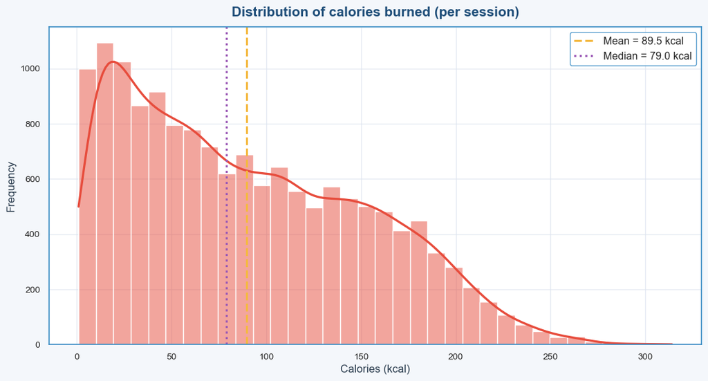

```python
fig, ax = plt.subplots(figsize=(11, 6), facecolor="#f4f7fb")

sns.histplot(
    df["calories"],
    bins=34,
    kde=True,
    color="#e74c3c",
    edgecolor="white",
    linewidth=1.0,
    line_kws={"color": PRIMARY, "lw": 2.4},
    ax=ax,
)

mu_c = df["calories"].mean()
md_c = df["calories"].median()
ax.axvline(mu_c, color=GOLD, ls="--", lw=2.3, label=f"Mean = {mu_c:.1f} kcal")
ax.axvline(md_c, color="#9b59b6", ls=":", lw=2.3, label=f"Median = {md_c:.1f} kcal")
ax.legend(loc="upper right", frameon=True)

ax.set_title("Distribution of calories burned (per session)", color=PRIMARY, fontsize=15, pad=12)
ax.set_xlabel("Calories (kcal)")
ax.set_ylabel("Frequency")
plt.tight_layout()
plt.show()
```

### **Calories burned distribution**

**Key visual:** Shows how often sessions land in low vs high burn buckets; red KDE traces the smooth trend.

- Most sessions cluster in **low–moderate** burn; a long right tail captures intense workouts.
- Right skew implies **rare high-burn events**—tree models handle this better than a single straight line.
- The gold mean line anchors the audience on a typical session before you show regression error.

**✔ Final insight:** The story is **everyday sessions dominate**, with occasional high-intensity outliers driving the tail.

### 🏃 Workout Duration vs Calories Burned

Now we analyze the relationship between exercise duration and calories burned.

This is one of the most important relationships in the entire project.

### DURATION VS CALORIES

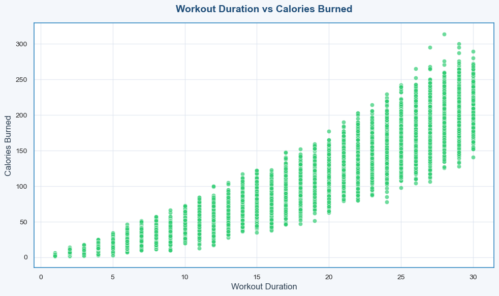

```python
plt.figure(figsize=(10,6))

sns.scatterplot(
    x=df["duration"],
    y=df["calories"],
    color="#2ecc71",
    alpha=0.7
)

plt.title("Workout Duration vs Calories Burned", pad=15)
plt.xlabel("Workout Duration")
plt.ylabel("Calories Burned")

plt.tight_layout()
plt.show()
```

### **Duration vs calories**

**✔ Final insight:** Duration is the dominant driver—this figure is the visual proof before the model section.

### CORRELATION HEATMAP

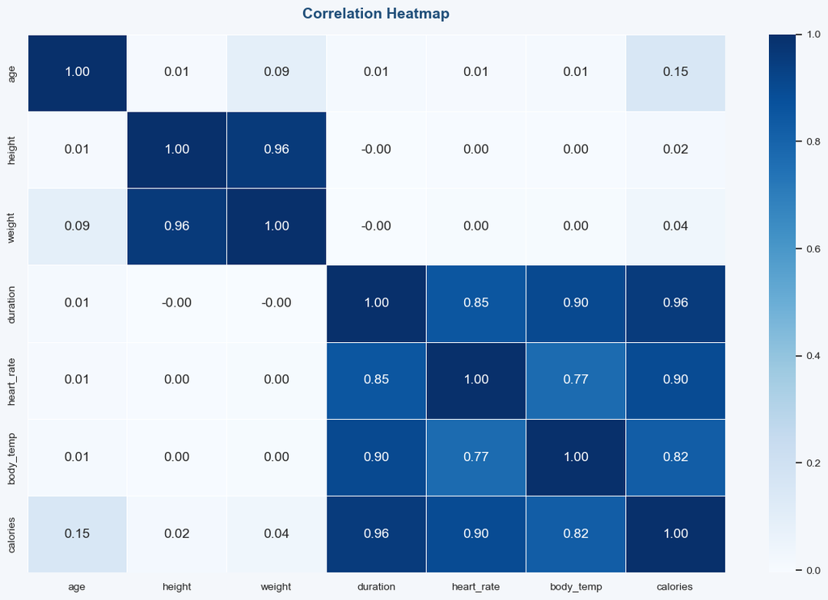

```python
plt.figure(figsize=(12,8))

corr = df.corr(numeric_only=True)

sns.heatmap(
    corr,
    annot=True,
    cmap="Blues",
    linewidths=0.5,
    fmt=".2f"
)

plt.title("Correlation Heatmap", pad=15)

plt.tight_layout()
plt.show()
```

### **Correlation heatmap**

[output not shown]

**✔ Final insight:** The heatmap backs the story that **workload signals**, not static body size alone, dominate session calories.

### Heart Rate vs Calories Burned

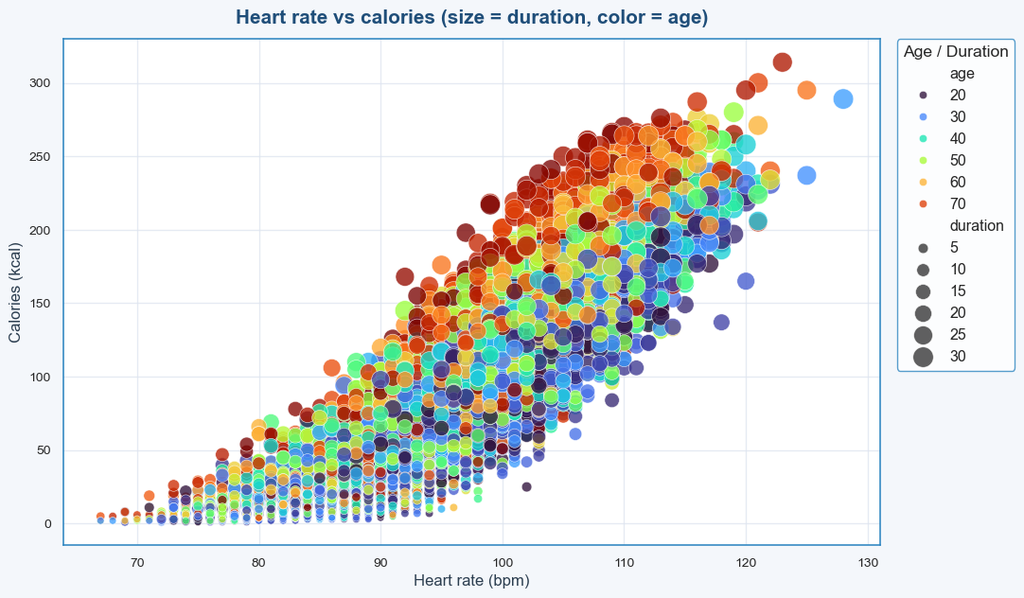

```python
fig, ax = plt.subplots(figsize=(11, 6.5), facecolor="#f4f7fb")

sns.scatterplot(
    data=df,
    x="heart_rate",
    y="calories",
    size="duration",
    sizes=(30, 240),
    hue="age",
    palette="turbo",
    alpha=0.78,
    edgecolor="white",
    linewidth=0.45,
    ax=ax,
)

ax.set_title("Heart rate vs calories (size = duration, color = age)", color=PRIMARY, fontsize=15, pad=12)
ax.set_xlabel("Heart rate (bpm)")
ax.set_ylabel("Calories (kcal)")
handles, labels = ax.get_legend_handles_labels()
ax.legend(handles, labels, title="Age / Duration", bbox_to_anchor=(1.02, 1), loc="upper left", borderaxespad=0, frameon=True)
plt.tight_layout()
plt.show()
```

### **Heart rate vs calories**

**Key visual:** Bubble size encodes duration; color encodes age—three variables in one plane.

- Upward drift confirms **intensity** (HR) aligns with higher burn when duration is held in mind via size.
- Color streaks show age bands—useful to discuss whether older participants cluster at lower HR for the same calories.
- Encodings make the chart dense; narrate one encoding at a time so the audience can follow.

**✔ Final insight:** Burn is a **multi-factor** story: HR + time + person-level context, not HR alone.

### Top 10 High-Protein Foods

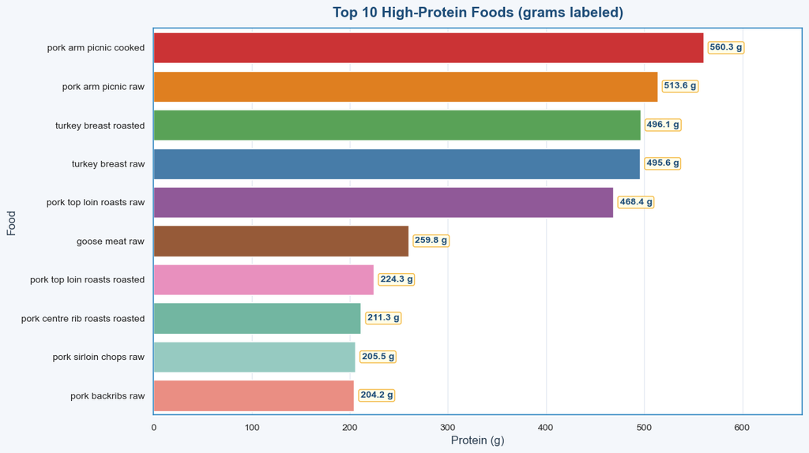

```python
# ============================================================
# TOP 10 HIGH-PROTEIN FOODS
# ============================================================

top_protein = food_df.sort_values("protein", ascending=False).head(10)

fig, ax = plt.subplots(figsize=(12, 6.8), facecolor="#f4f7fb")

pal = [
    "#e41a1c", "#ff7f00", "#4daf4a", "#377eb8", "#984ea3",
    "#a65628", "#f781bf", "#66c2a5", "#8dd3c7", "#fb8072"
]

sns.barplot(
    data=top_protein,
    x="protein",
    y="food",
    palette=pal,
    edgecolor="white",
    linewidth=1.0,
    ax=ax
)

ax.set_title(
    "Top 10 High-Protein Foods (grams labeled)",
    color=PRIMARY,
    fontsize=15,
    pad=12
)

ax.set_xlabel("Protein (g)")
ax.set_ylabel("Food")

xmax = float(top_protein["protein"].max())

for p in ax.patches:
    w = p.get_width()
    ax.text(
        w + xmax * 0.012,
        p.get_y() + p.get_height() / 2,
        f"{w:.1f} g",
        va="center",
        fontsize=10,
        fontweight="bold",
        color=PRIMARY,
        bbox=dict(
            boxstyle="round,pad=0.2",
            facecolor="#fffde7",
            edgecolor=GOLD,
            alpha=0.95
        ),
    )

ax.set_xlim(0, xmax * 1.18)

plt.tight_layout()
plt.show()
```

### **Top protein bar chart (labeled grams)**

**Key visual:** Horizontal bars rank foods; numeric labels show exact protein so the audience reads precise winners.

- Leaders are protein-dense items—often animal-based in this slice of the table.
- Wide gaps between bars signal **very different** protein budgets for the same meal planning window.
- Pair this chart with the calorie–protein scatter to discuss **density**, not only raw grams.

**✔ Final insight:** High protein is actionable for recommendations, but must be balanced with fat, sodium, and personal preference.

### CALORIES VS PROTEIN

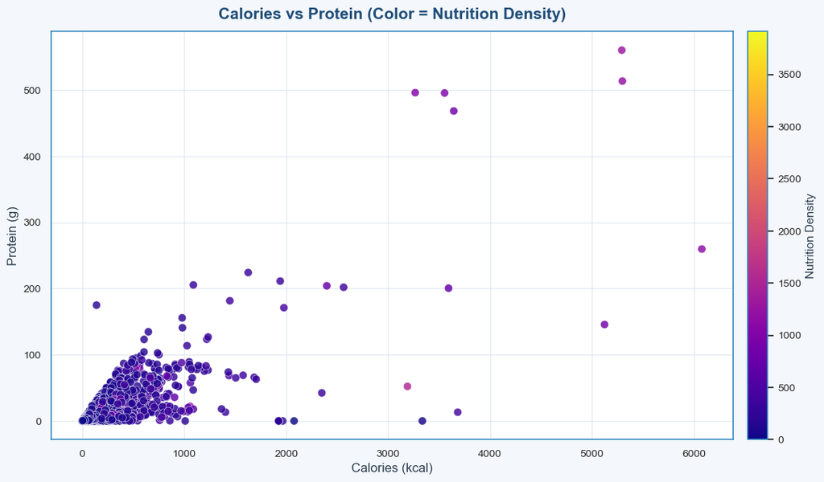

```python
fig, ax = plt.subplots(figsize=(11, 6.5), facecolor="#f4f7fb")

sc = sns.scatterplot(
    data=food_df,
    x="caloric_value",
    y="protein",
    hue="nutrition_density",
    palette="plasma",
    alpha=0.82,
    s=58,
    edgecolor="white",
    linewidth=0.4,
    legend=False,
    ax=ax,
)

# Color scale
norm = plt.Normalize(
    food_df["nutrition_density"].min(),
    food_df["nutrition_density"].max()
)

sm = plt.cm.ScalarMappable(
    cmap="plasma",
    norm=norm
)

sm.set_array([])

cb = fig.colorbar(
    sm,
    ax=ax,
    fraction=0.046,
    pad=0.02
)

cb.set_label("Nutrition Density", fontsize=11)

ax.set_title(
    "Calories vs Protein (Color = Nutrition Density)",
    color=PRIMARY,
    fontsize=15,
    pad=12
)

ax.set_xlabel("Calories (kcal)")
ax.set_ylabel("Protein (g)")

plt.tight_layout()
plt.show()
```

### **Calories vs protein (color = nutrition density)**

**Key visual:** Each point is a food; plasma colors encode nutrition_density—higher is ‘more nutrients per calorie’.

- Most foods sit in a **low–mid calorie cloud**; a few outliers carry huge protein at high calories.
- Color separates ‘empty calories’ from ‘nutrient rich’ even when kcal is similar.
- This motivates the recommender to rank by **density**, not kcal alone.

**✔ Final insight:** Protein without density context can mislead; the color channel fixes that for storytelling.

### TOP 10 CUISINES — RECIPE DATASET

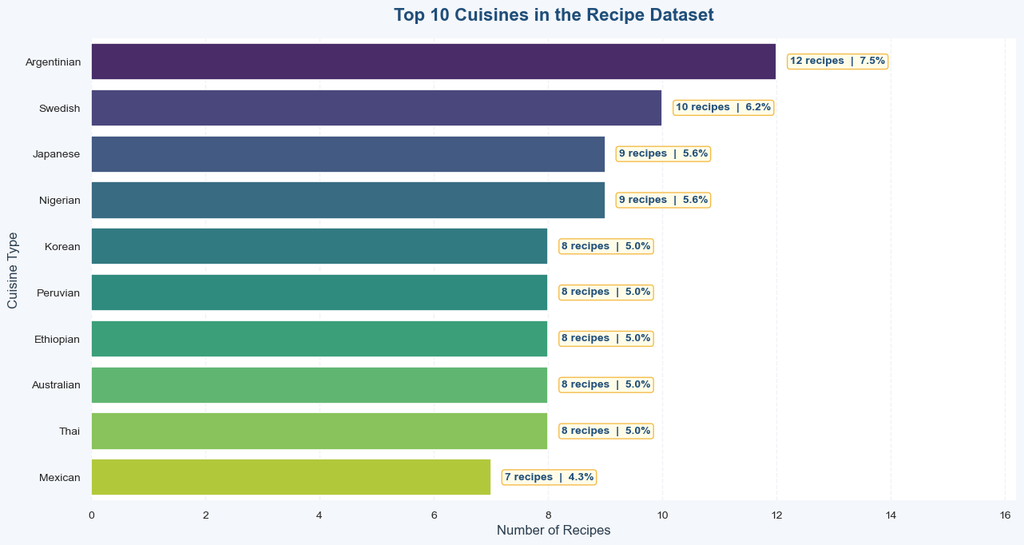

```python
cuisine_counts = recipes_df["cuisine"].value_counts().head(10)
total_recipes = len(recipes_df)

cuisine_plot_df = cuisine_counts.reset_index()
cuisine_plot_df.columns = ["Cuisine", "Recipe_Count"]
cuisine_plot_df["Percentage"] = (cuisine_plot_df["Recipe_Count"] / total_recipes) * 100

fig, ax = plt.subplots(figsize=(13, 7), facecolor="#f4f7fb")

palette = sns.color_palette("viridis", n_colors=len(cuisine_plot_df))

bars = sns.barplot(
    data=cuisine_plot_df,
    x="Recipe_Count",
    y="Cuisine",
    palette=palette,
    edgecolor="white",
    linewidth=1.2,
    ax=ax
)

ax.set_title(
    "Top 10 Cuisines in the Recipe Dataset",
    color=PRIMARY,
    fontsize=16,
    fontweight="bold",
    pad=16
)

ax.set_xlabel("Number of Recipes", fontsize=12)
ax.set_ylabel("Cuisine Type", fontsize=12)

vmax = cuisine_plot_df["Recipe_Count"].max()

for i, row in cuisine_plot_df.iterrows():
    ax.text(
        row["Recipe_Count"] + vmax * 0.02,
        i,
        f'{int(row["Recipe_Count"])} recipes  |  {row["Percentage"]:.1f}%',
        va="center",
        fontsize=10,
        fontweight="bold",
        color=PRIMARY,
        bbox=dict(
            boxstyle="round,pad=0.25",
            facecolor="#fffde7",
            edgecolor=GOLD,
            alpha=0.95
        )
    )

ax.set_xlim(0, vmax * 1.35)

ax.grid(axis="x", linestyle="--", alpha=0.45)
ax.grid(axis="y", visible=False)

sns.despine(left=True, bottom=True)

plt.tight_layout()
plt.show()
```

### **Cuisine counts in recipe data**

**Key visual:** Horizontal bars show how many recipes each cuisine contributes (top 10).

- Counts are relatively even across cuisines—good for **variety** in meal suggestions.
- Argentine / Swedish / Japanese / Nigerian appear often; use this to discuss global coverage.
- Small *n* per cuisine is a limitation—averages later should be read cautiously.

**✔ Final insight:** Diversity here supports diverse recipe recommendations without over-fitting one cuisine.

### Top 10 Recipes with Longest Cooking Time

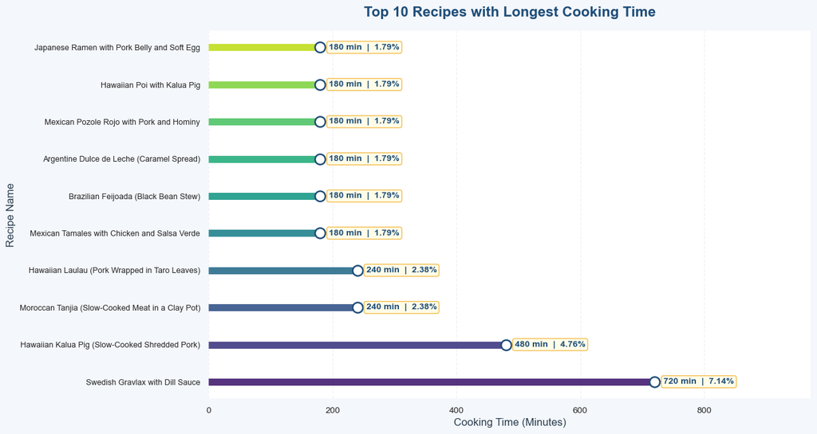

```python
top_cook = (
    recipes_df
    .sort_values("cooking_time_minutes", ascending=False)
    .head(10)
    .copy()
)

# Percentage contribution
total_time = recipes_df["cooking_time_minutes"].sum()

top_cook["time_percentage"] = (
    top_cook["cooking_time_minutes"] / total_time
) * 100

fig, ax = plt.subplots(figsize=(13, 7), facecolor="#f4f7fb")

y_pos = np.arange(len(top_cook))

line_colors = sns.color_palette(
    "viridis",
    n_colors=len(top_cook)
)

# Horizontal lines
for yi, val, lc in zip(
    y_pos,
    top_cook["cooking_time_minutes"],
    line_colors
):
    ax.hlines(
        y=yi,
        xmin=0,
        xmax=val,
        colors=lc,
        linewidth=8,
        alpha=0.92
    )

# Circle markers
ax.scatter(
    top_cook["cooking_time_minutes"],
    y_pos,
    color="white",
    edgecolor=PRIMARY,
    s=135,
    zorder=3,
    linewidth=1.8
)

# Labels
ax.set_yticks(y_pos)

ax.set_yticklabels(
    top_cook["recipe_name"],
    fontsize=9
)

ax.set_xlabel(
    "Cooking Time (Minutes)",
    fontsize=12
)

ax.set_ylabel(
    "Recipe Name",
    fontsize=12
)

ax.set_title(
    "Top 10 Recipes with Longest Cooking Time",
    color=PRIMARY,
    fontsize=16,
    fontweight="bold",
    pad=16
)

# Value labels
xmax = float(top_cook["cooking_time_minutes"].max())

for i, row in top_cook.iterrows():

    ax.text(
        row["cooking_time_minutes"] + xmax * 0.02,
        list(top_cook.index).index(i),

        f'{int(row["cooking_time_minutes"])} min  |  {row["time_percentage"]:.2f}%',

        va="center",
        fontsize=10,
        fontweight="bold",
        color=PRIMARY,

        bbox=dict(
            boxstyle="round,pad=0.25",
            facecolor="#fffde7",
            edgecolor=GOLD,
            alpha=0.95
        )
    )

# Style improvements
ax.grid(axis="x", linestyle="--", alpha=0.45)
ax.grid(axis="y", visible=False)

sns.despine(left=True, bottom=True)

ax.set_xlim(0, xmax * 1.35)

plt.tight_layout()
plt.show()
```

### **Cooking time lollipop chart**

- Times stretch from ~3 hours up to ~12 hours for slow preparations.
- Long cooks cluster on traditional dishes—great for ‘time budget’ questions in class.
- Use minutes on-chart to avoid hand-waving about which recipe is truly longest.

**✔ Final insight:** Time is a practical constraint the recommender can respect alongside calories.

### TOP CUISINES BY AVERAGE CALORIES PER SERVING

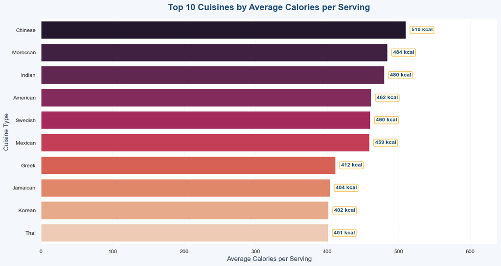

```python
avg_calories = (
    recipes_df
    .groupby("cuisine")["calories_per_serving"]
    .mean()
    .sort_values(ascending=False)
    .head(10)
    .reset_index()
)

avg_calories.columns = ["Cuisine", "Avg_Calories_Per_Serving"]

fig, ax = plt.subplots(figsize=(13, 7), facecolor="#f4f7fb")

palette = sns.color_palette("rocket", n_colors=len(avg_calories))

sns.barplot(
    data=avg_calories,
    x="Avg_Calories_Per_Serving",
    y="Cuisine",
    palette=palette,
    edgecolor="white",
    linewidth=1.2,
    ax=ax
)

ax.set_title(
    "Top 10 Cuisines by Average Calories per Serving",
    color=PRIMARY,
    fontsize=16,
    fontweight="bold",
    pad=16
)

ax.set_xlabel("Average Calories per Serving", fontsize=12)
ax.set_ylabel("Cuisine Type", fontsize=12)

xmax = avg_calories["Avg_Calories_Per_Serving"].max()

for i, row in avg_calories.iterrows():
    ax.text(
        row["Avg_Calories_Per_Serving"] + xmax * 0.015,
        i,
        f'{row["Avg_Calories_Per_Serving"]:.0f} kcal',
        va="center",
        fontsize=10,
        fontweight="bold",
        color=PRIMARY,
        bbox=dict(
            boxstyle="round,pad=0.25",
            facecolor="#fffde7",
            edgecolor=GOLD,
            alpha=0.95
        )
    )

ax.set_xlim(0, xmax * 1.25)
ax.grid(axis="x", linestyle="--", alpha=0.45)
ax.grid(axis="y", visible=False)

sns.despine(left=True, bottom=True)

plt.tight_layout()
plt.show()
```

### **Average calories per serving by cuisine**

- Higher bars imply richer or larger-portion styles on average—**not** a judgment of health, a data fact.
- Ordering makes trade-offs visible when pairing with the diversity chart before it.
- Good bridge to recipe filtering: pick cuisines under a calorie ceiling for a user goal.

**✔ Final insight:** Cuisine-level averages guide storytelling; individual recipes still vary inside each bar.

### HEIGHT VS WEIGHT — DENSITY + MEAN REFERENCE LINES

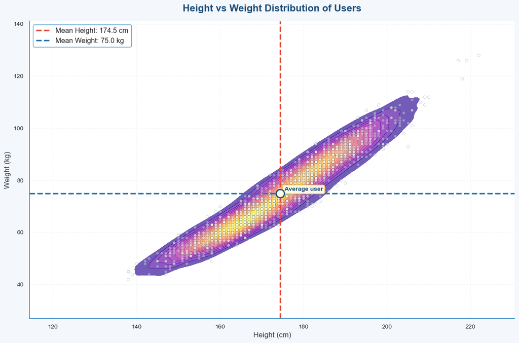

```python
fig, ax = plt.subplots(figsize=(12, 8), facecolor="#f4f7fb")

sns.kdeplot(
    data=df,
    x="height",
    y="weight",
    cmap="plasma",
    fill=True,
    thresh=0.04,
    levels=18,
    alpha=0.65,
    ax=ax
)

sns.scatterplot(
    data=df.sample(min(1200, len(df)), random_state=42),
    x="height",
    y="weight",
    color="white",
    edgecolor="#2c3e50",
    alpha=0.32,
    s=22,
    linewidth=0.45,
    ax=ax
)

mean_height = df["height"].mean()
mean_weight = df["weight"].mean()

ax.axvline(
    mean_height,
    color="#e74c3c",
    linestyle="--",
    lw=2.4,
    label=f"Mean Height: {mean_height:.1f} cm"
)

ax.axhline(
    mean_weight,
    color="#1f77b4",
    linestyle="--",
    lw=2.4,
    label=f"Mean Weight: {mean_weight:.1f} kg"
)

ax.scatter(
    mean_height,
    mean_weight,
    s=180,
    color="#fffde7",
    edgecolor=PRIMARY,
    linewidth=2,
    zorder=5
)

ax.text(
    mean_height + 1,
    mean_weight + 1,
    "Average user",
    fontsize=10,
    fontweight="bold",
    color=PRIMARY,
    bbox=dict(
        boxstyle="round,pad=0.3",
        facecolor="#fffde7",
        edgecolor=GOLD,
        alpha=0.95
    )
)

ax.set_title(
    "Height vs Weight Distribution of Users",
    color=PRIMARY,
    fontsize=16,
    fontweight="bold",
    pad=16
)

ax.set_xlabel("Height (cm)", fontsize=12)
ax.set_ylabel("Weight (kg)", fontsize=12)

ax.legend(
    loc="upper left",
    frameon=True,
    facecolor="white",
    edgecolor=ACCENT
)

ax.grid(alpha=0.35, linestyle="--")

sns.despine(left=False, bottom=False)

plt.tight_layout()
plt.show()
```

### ✅ Interpretation

This chart shows the relationship between user height and weight.

This is useful because height and weight are important body-related variables.  
Later, we can use them to create BMI, which may help improve calorie prediction.

### MULTI-FACTOR CALORIE ANALYSIS (Duration, Heart Rate, and Calories)

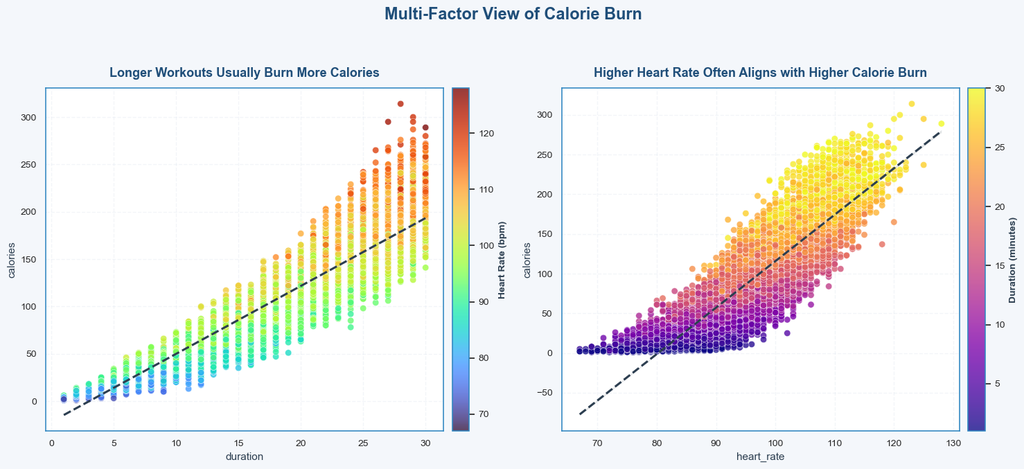

```python
fig, (ax1, ax2) = plt.subplots(
    1, 2,
    figsize=(15, 6.5),
    facecolor="#f4f7fb"
)

# ------------------------------------------------------------
# Chart 1: Duration vs Calories, colored by Heart Rate
# ------------------------------------------------------------
sc1 = ax1.scatter(
    df["duration"],
    df["calories"],
    c=df["heart_rate"],
    cmap="turbo",
    s=45,
    alpha=0.78,
    edgecolors="white",
    linewidths=0.4
)

cb1 = fig.colorbar(
    sc1,
    ax=ax1,
    fraction=0.046,
    pad=0.02
)

cb1.set_label(
    "Heart Rate (bpm)",
    fontsize=10,
    fontweight="bold"
)

ax1.set_title(
    "Longer Workouts Usually Burn More Calories",
    color=PRIMARY,
    fontsize=13,
    fontweight="bold",
    pad=12
)

ax1.set_xlabel("Workout Duration (minutes)", fontsize=11)
ax1.set_ylabel("Calories Burned (kcal)", fontsize=11)

# Trend line
sns.regplot(
    data=df,
    x="duration",
    y="calories",
    scatter=False,
    ax=ax1,
    color="#2c3e50",
    line_kws={"linewidth": 2.2, "linestyle": "--"}
)

ax1.grid(alpha=0.35, linestyle="--")


# ------------------------------------------------------------
# Chart 2: Heart Rate vs Calories, colored by Duration
# ------------------------------------------------------------
sc2 = ax2.scatter(
    df["heart_rate"],
    df["calories"],
    c=df["duration"],
    cmap="plasma",
    s=45,
    alpha=0.78,
    edgecolors="white",
    linewidths=0.4
)

cb2 = fig.colorbar(
    sc2,
    ax=ax2,
    fraction=0.046,
    pad=0.02
)

cb2.set_label(
    "Duration (minutes)",
    fontsize=10,
    fontweight="bold"
)

ax2.set_title(
    "Higher Heart Rate Often Aligns with Higher Calorie Burn",
    color=PRIMARY,
    fontsize=13,
    fontweight="bold",
    pad=12
)

ax2.set_xlabel("Heart Rate (bpm)", fontsize=11)
ax2.set_ylabel("Calories Burned (kcal)", fontsize=11)

# Trend line
sns.regplot(
    data=df,
    x="heart_rate",
    y="calories",
    scatter=False,
    ax=ax2,
    color="#2c3e50",
    line_kws={"linewidth": 2.2, "linestyle": "--"}
)

ax2.grid(alpha=0.35, linestyle="--")


# ------------------------------------------------------------
# Main title
# ------------------------------------------------------------
fig.suptitle(
    "Multi-Factor View of Calorie Burn",
    color=PRIMARY,
    fontsize=17,
    fontweight="bold",
    y=1.04
)

plt.tight_layout()
plt.show()
```

### **Multi-factor relationships (2D panels)**

**Key visual:** Two side-by-side scatter plots share the same outcome (**calories**) but swap which driver is on the x-axis and which is encoded as color.

| Panel | X-axis | Color | Takeaway |
| --- | --- | --- | --- |
| Left | Duration | Heart rate | Time-on-task with intensity layered in |
| Right | Heart rate | Duration | Intensity-first view with time as hue |

- Both panels reinforce that calories rise when **workload** rises—without the occlusion of a single 3D view.
- Pair this slide with the correlation heatmap for a clean classroom narrative.

**✔ Final insight:** Two crisp plots usually communicate faster than one crowded 3D rotation.

## EDA Summary

Exploratory Data Analysis helped us understand important patterns inside the datasets.

We discovered:

- User age and gender distributions
- Calories burned patterns
- Strong relationship between duration and calories
- Important correlations between health variables

This analysis now gives us a strong understanding of the data before moving into feature engineering and machine learning.

# ⚙️ Part 6 — Feature Engineering

After completing Exploratory Data Analysis (EDA), we now create new intelligent features that improve machine learning prediction, recommendation quality, and AI understanding.

Feature engineering transforms raw health and nutrition data into more meaningful numerical information that better represents exercise intensity, body composition, and food quality.

- Creating BMI from height and weight
- Measuring calories burned efficiency per minute
- Calculating workout intensity using heart rate
- Creating nutrition density for food quality analysis
- Generating protein and fat ratio features
- Preparing smarter inputs for ML and recommendation systems

These engineered features help the system better understand user health behavior, workout performance, and nutrition quality.

Strong feature engineering is one of the most important parts of data science because better features often lead to more accurate predictions and smarter personalized recommendations.

```
══════════════════════════════════════════════════════════════════════════════════════════
PART 6 — FEATURE ENGINEERING
Creating smarter features for ML, recommendation, and AI explanation
══════════════════════════════════════════════════════════════════════════════════════════

✅ BMI feature created:
```

|  | height | weight | bmi |
| --- | --- | --- | --- |
| 0 | 190 | 94 | 26.038781 |
| 1 | 166 | 60 | 21.773842 |
| 2 | 179 | 79 | 24.655910 |
| 3 | 179 | 71 | 22.159109 |
| 4 | 154 | 58 | 24.456063 |

```
✅ Calories per minute feature created:
```

|  | calories | duration | calories_per_minute |
| --- | --- | --- | --- |
| 0 | 231 | 29 | 7.965517 |
| 1 | 66 | 14 | 4.714286 |
| 2 | 26 | 5 | 5.200000 |
| 3 | 71 | 13 | 5.461538 |
| 4 | 35 | 10 | 3.500000 |

```
✅ Heart rate intensity feature created:
```

|  | heart_rate | duration | heart_rate_intensity |
| --- | --- | --- | --- |
| 0 | 105 | 29 | 3.620690 |
| 1 | 94 | 14 | 6.714286 |
| 2 | 88 | 5 | 17.600000 |
| 3 | 100 | 13 | 7.692308 |
| 4 | 81 | 10 | 8.100000 |

```
✅ Nutrition density feature created:
```

|  | food | caloric_value | protein | dietary_fiber | nutrition_density |
| --- | --- | --- | --- | --- | --- |
| 0 | cream cheese | 51 | 0.9 | 0.0 | 0.017308 |
| 1 | neufchatel cheese | 215 | 7.8 | 0.0 | 0.036111 |
| 2 | requeijao cremoso light catupiry | 49 | 0.8 | 0.1 | 0.018000 |
| 3 | ricotta cheese | 30 | 1.5 | 0.0 | 0.048387 |
| 4 | cream cheese low fat | 30 | 1.2 | 0.0 | 0.038710 |

```
✅ Protein ratio and fat ratio created:
```

|  | food | caloric_value | protein | fat | protein_ratio | fat_ratio |
| --- | --- | --- | --- | --- | --- | --- |
| 0 | cream cheese | 51 | 0.9 | 5.0 | 0.017308 | 0.096154 |
| 1 | neufchatel cheese | 215 | 7.8 | 19.4 | 0.036111 | 0.089815 |
| 2 | requeijao cremoso light catupiry | 49 | 0.8 | 3.6 | 0.016000 | 0.072000 |
| 3 | ricotta cheese | 30 | 1.5 | 2.0 | 0.048387 | 0.064516 |
| 4 | cream cheese low fat | 30 | 1.2 | 2.3 | 0.038710 | 0.074194 |

```
══════════════════════════════════════════════════════════════════════════════════════════
ENGINEERED FEATURES CREATED
══════════════════════════════════════════════════════════════════════════════════════════

User / exercise dataset new features:
✅ bmi
✅ calories_per_minute
✅ heart_rate_intensity

Food nutrition dataset new features:
✅ nutrition_density
✅ protein_ratio
✅ fat_ratio
```

|  | Dataset | New Feature | Purpose |
| --- | --- | --- | --- |
| 0 | User Exercise Dataset | bmi | Combines height and weight into a body-composi... |
| 1 | User Exercise Dataset | calories_per_minute | Measures how many calories are burned per minute |
| 2 | User Exercise Dataset | heart_rate_intensity | Measures workout intensity using heart rate an... |
| 3 | Food Nutrition Dataset | nutrition_density | Ranks food quality using protein, fiber, and c... |
| 4 | Food Nutrition Dataset | protein_ratio | Compares protein amount relative to calories |
| 5 | Food Nutrition Dataset | fat_ratio | Compares fat amount relative to calories |

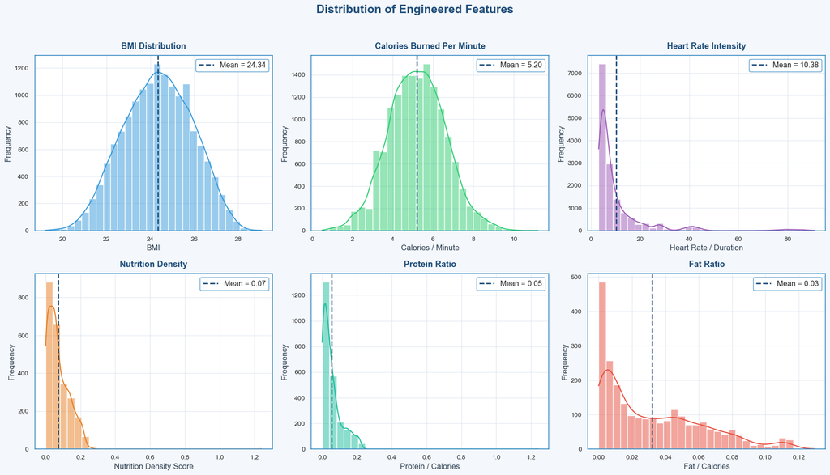

```
✅ Part 6 completed successfully.
```

```python
print("═" * 90)
print("PART 6 — FEATURE ENGINEERING")
print("Creating smarter features for ML, recommendation, and AI explanation")
print("═" * 90)

# ------------------------------------------------------------
# 1. BMI FEATURE
# ------------------------------------------------------------
# BMI combines height and weight into one health-related feature.
# Height is in centimeters, so we convert it to meters.

df["bmi"] = df["weight"] / ((df["height"] / 100) ** 2)

print("\n✅ BMI feature created:")
display(df[["height", "weight", "bmi"]].head())


# ------------------------------------------------------------
# 2. CALORIES PER MINUTE
# ------------------------------------------------------------
# This measures workout efficiency.

df["calories_per_minute"] = df["calories"] / df["duration"]

print("\n✅ Calories per minute feature created:")
display(df[["calories", "duration", "calories_per_minute"]].head())


# ------------------------------------------------------------
# 3. HEART RATE INTENSITY
# ------------------------------------------------------------
# This measures workout intensity relative to duration.

df["heart_rate_intensity"] = df["heart_rate"] / df["duration"]

print("\n✅ Heart rate intensity feature created:")
display(df[["heart_rate", "duration", "heart_rate_intensity"]].head())


# ------------------------------------------------------------
# 4. NUTRITION DENSITY
# ------------------------------------------------------------
# Nutrition density rewards foods with higher protein and fiber
# while controlling for calories.

food_df["nutrition_density"] = (
    food_df["protein"] + food_df["dietary_fiber"]
) / (food_df["caloric_value"] + 1)

print("\n✅ Nutrition density feature created:")
display(
    food_df[
        ["food", "caloric_value", "protein", "dietary_fiber", "nutrition_density"]
    ].head()
)


# ------------------------------------------------------------
# 5. PROTEIN RATIO
# ------------------------------------------------------------
# Protein ratio compares protein amount relative to calories.

food_df["protein_ratio"] = (
    food_df["protein"] / (food_df["caloric_value"] + 1)
)


# ------------------------------------------------------------
# 6. FAT RATIO
# ------------------------------------------------------------
# Fat ratio compares fat amount relative to calories.

food_df["fat_ratio"] = (
    food_df["fat"] / (food_df["caloric_value"] + 1)
)

print("\n✅ Protein ratio and fat ratio created:")
display(
    food_df[
        ["food", "caloric_value", "protein", "fat", "protein_ratio", "fat_ratio"]
    ].head()
)


# ------------------------------------------------------------
# 7. FINAL FEATURE CHECK
# ------------------------------------------------------------

engineered_user_features = [
    "bmi",
    "calories_per_minute",
    "heart_rate_intensity"
]

engineered_food_features = [
    "nutrition_density",
    "protein_ratio",
    "fat_ratio"
]

print("\n" + "═" * 90)
print("ENGINEERED FEATURES CREATED")
print("═" * 90)

print("\nUser / exercise dataset new features:")
for col in engineered_user_features:
    print(f"✅ {col}")

print("\nFood nutrition dataset new features:")
for col in engineered_food_features:
    print(f"✅ {col}")


# ------------------------------------------------------------
# 8. FEATURE SUMMARY TABLE
# ------------------------------------------------------------

feature_summary = pd.DataFrame({
    "Dataset": [
        "User Exercise Dataset",
        "User Exercise Dataset",
        "User Exercise Dataset",
        "Food Nutrition Dataset",
        "Food Nutrition Dataset",
        "Food Nutrition Dataset"
    ],
    "New Feature": [
        "bmi",
        "calories_per_minute",
        "heart_rate_intensity",
        "nutrition_density",
        "protein_ratio",
        "fat_ratio"
    ],
    "Purpose": [
        "Combines height and weight into a body-composition indicator",
        "Measures how many calories are burned per minute",
        "Measures workout intensity using heart rate and duration",
        "Ranks food quality using protein, fiber, and calories",
        "Compares protein amount relative to calories",
        "Compares fat amount relative to calories"
    ]
})

display(feature_summary)


# ------------------------------------------------------------
# 9. BEAUTIFUL FEATURE VISUALIZATION
# ------------------------------------------------------------

fig, axes = plt.subplots(2, 3, figsize=(18, 10), facecolor="#f4f7fb")

feature_plots = [
    (df["bmi"], "BMI Distribution", "BMI", "#3498db"),
    (df["calories_per_minute"], "Calories Burned Per Minute", "Calories / Minute", "#2ecc71"),
    (df["heart_rate_intensity"], "Heart Rate Intensity", "Heart Rate / Duration", "#9b59b6"),
    (food_df["nutrition_density"], "Nutrition Density", "Nutrition Density Score", "#e67e22"),
    (food_df["protein_ratio"], "Protein Ratio", "Protein / Calories", "#1abc9c"),
    (food_df["fat_ratio"], "Fat Ratio", "Fat / Calories", "#e74c3c")
]

for ax, (data, title, xlabel, color) in zip(axes.flatten(), feature_plots):

    sns.histplot(
        data.dropna(),
        bins=30,
        kde=True,
        color=color,
        edgecolor="white",
        linewidth=1,
        ax=ax
    )

    mean_value = data.mean()

    ax.axvline(
        mean_value,
        color=PRIMARY,
        linestyle="--",
        linewidth=2,
        label=f"Mean = {mean_value:.2f}"
    )

    ax.set_title(
        title,
        color=PRIMARY,
        fontsize=13,
        fontweight="bold",
        pad=10
    )

    ax.set_xlabel(xlabel)
    ax.set_ylabel("Frequency")
    ax.legend()

plt.suptitle(
    "Distribution of Engineered Features",
    fontsize=18,
    fontweight="bold",
    color=PRIMARY,
    y=1.02
)

plt.tight_layout()
plt.show()


print("\n✅ Part 6 completed successfully.")
```

## ✅ After Part 6 — Feature Engineering Results

In this part, we successfully created several intelligent features that will improve machine learning prediction and recommendation quality.

### 🧍 BMI Feature

The average BMI is approximately **24.34**, which falls near the healthy-to-slightly-overweight range.

The BMI distribution looks close to a normal distribution, meaning the dataset contains a balanced variety of body types.

This feature will help the calorie prediction model better understand body composition and energy usage.

### 🔥 Calories Burned Per Minute

The average calories burned per minute is around **5.20 calories/minute**.

Most users cluster between moderate workout efficiency ranges, while a smaller number achieve very high calorie burn rates.

This feature helps measure workout effectiveness instead of only total calories burned.

### ❤️ Heart Rate Intensity

The average heart rate intensity is approximately **10.38**.

The distribution is strongly right-skewed, meaning most workouts have moderate intensity while a smaller number represent very intense exercise sessions.

This feature helps the model understand workout intensity beyond simple heart rate values.

### 🥗 Nutrition Density

The average nutrition density score is around **0.07**.

Foods with higher nutrition density generally provide:

- More protein
- More dietary fiber
- Better nutrient balance relative to calories

This feature will help rank healthier food recommendations later in the project.

### ⚖️ Protein Ratio & Fat Ratio

The average protein ratio is approximately **0.05**, while the average fat ratio is around **0.03**.

These ratios help compare foods fairly by adjusting nutrients relative to calories.

This is important because:

- High protein ratio foods may support fitness and muscle recovery
- High fat ratio foods may indicate calorie-dense foods
- The recommendation system can better personalize food suggestions

### 📌 Final Summary

The datasets are now transformed from raw data into **AI-ready intelligent datasets**.

We successfully engineered features that capture:

- Body composition
- Workout efficiency
- Exercise intensity
- Nutrition quality
- Nutrient balance

These engineered features will become highly valuable during:

- Machine learning calorie prediction
- Food recommendation ranking
- Nutrition intelligence analysis
- AI/RAG explanation generation

# 🤖 Part 7 — Machine Learning: Calorie Prediction

In this section, we build machine learning models to predict the number of calories burned based on user body information and exercise activity.

The models learn patterns from exercise duration, heart rate, BMI, body temperature, and other engineered features to estimate calorie burn accurately.

- Preparing features and target variables
- Encoding categorical variables
- Splitting data into training and testing sets
- Training multiple machine learning models
- Evaluating model performance using MAE, RMSE, and R²
- Selecting the best prediction model

We compare multiple algorithms to identify which model predicts calories burned most accurately and reliably.

The final selected model will later power the personalized recommendation system and AI nutrition assistant.

```
══════════════════════════════════════════════════════════════════════════════════════════
PART 7 — MACHINE LEARNING: CALORIE PREDICTION
Training ML models to predict calories burned
══════════════════════════════════════════════════════════════════════════════════════════

✅ Gender column encoded successfully.

✅ Features selected:
['gender', 'age', 'height', 'weight', 'duration', 'heart_rate', 'body_temp', 'bmi', 'calories_per_minute', 'heart_rate_intensity']

Feature matrix shape: (15000, 10)
Target shape: (15000,)

✅ Train-test split completed.
Training size: (12000, 10)
Testing size: (3000, 10)

──────────────────────────────────────────────────────────────────────
Training Linear Regression...
✅ Linear Regression completed.
MAE:  7.148
RMSE: 9.603
R²:   0.9772

──────────────────────────────────────────────────────────────────────
Training Random Forest...
✅ Random Forest completed.
MAE:  0.142
RMSE: 0.585
R²:   0.9999

──────────────────────────────────────────────────────────────────────
Training Gradient Boosting...
✅ Gradient Boosting completed.
MAE:  1.394
RMSE: 1.818
R²:   0.9992
```

|  | Model | MAE | RMSE | R² Score |
| --- | --- | --- | --- | --- |
| 0 | Linear Regression | 7.148 | 9.603 | 0.9772 |
| 1 | Random Forest | 0.142 | 0.585 | 0.9999 |
| 2 | Gradient Boosting | 1.394 | 1.818 | 0.9992 |

```
══════════════════════════════════════════════════════════════════════════════════════════
BEST MODEL
══════════════════════════════════════════════════════════════════════════════════════════
🏆 Best Model: Random Forest
R² Score: 0.9999
RMSE: 0.585
```

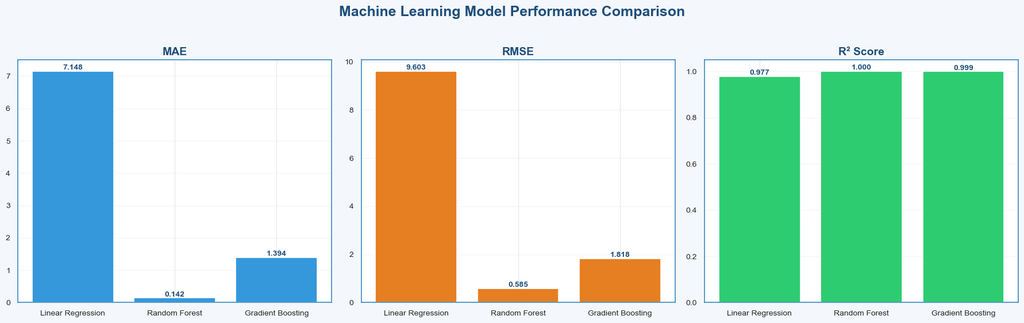

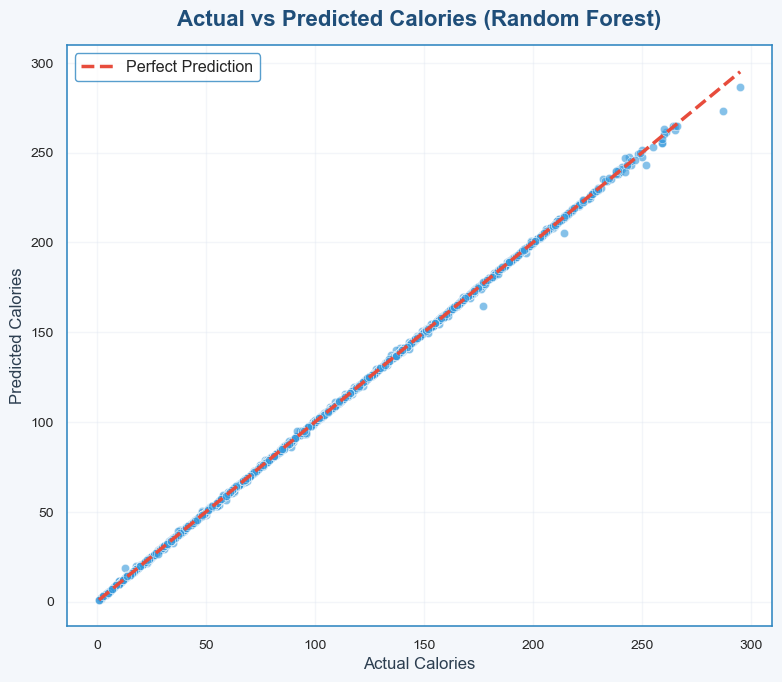

```
✅ Part 7 completed successfully.
```

```python
print("═" * 90)
print("PART 7 — MACHINE LEARNING: CALORIE PREDICTION")
print("Training ML models to predict calories burned")
print("═" * 90)

# ------------------------------------------------------------
# IMPORT MACHINE LEARNING LIBRARIES
# ------------------------------------------------------------

from sklearn.model_selection import train_test_split
from sklearn.preprocessing import LabelEncoder
from sklearn.metrics import (
    mean_absolute_error,
    mean_squared_error,
    r2_score
)

from sklearn.linear_model import LinearRegression
from sklearn.ensemble import RandomForestRegressor
from sklearn.ensemble import GradientBoostingRegressor

# ------------------------------------------------------------
# ENCODE GENDER COLUMN
# ------------------------------------------------------------

le = LabelEncoder()

df["gender"] = le.fit_transform(df["gender"])

print("\n✅ Gender column encoded successfully.")


# ------------------------------------------------------------
# SELECT FEATURES & TARGET
# ------------------------------------------------------------

features = [
    "gender",
    "age",
    "height",
    "weight",
    "duration",
    "heart_rate",
    "body_temp",
    "bmi",
    "calories_per_minute",
    "heart_rate_intensity"
]

target = "calories"

X = df[features]
y = df[target]

print("\n✅ Features selected:")
print(features)

print("\nFeature matrix shape:", X.shape)
print("Target shape:", y.shape)


# ------------------------------------------------------------
# TRAIN TEST SPLIT
# ------------------------------------------------------------

X_train, X_test, y_train, y_test = train_test_split(
    X,
    y,
    test_size=0.20,
    random_state=42
)

print("\n✅ Train-test split completed.")

print("Training size:", X_train.shape)
print("Testing size:", X_test.shape)


# ------------------------------------------------------------
# INITIALIZE MODELS
# ------------------------------------------------------------

models = {
    "Linear Regression": LinearRegression(),

    "Random Forest": RandomForestRegressor(
        n_estimators=100,
        random_state=42
    ),

    "Gradient Boosting": GradientBoostingRegressor(
        random_state=42
    )
}

# ------------------------------------------------------------
# TRAIN & EVALUATE MODELS
# ------------------------------------------------------------

results = []

predictions_dict = {}

for name, model in models.items():

    print("\n" + "─" * 70)
    print(f"Training {name}...")

    # Train
    model.fit(X_train, y_train)

    # Predict
    preds = model.predict(X_test)

    predictions_dict[name] = preds

    # Metrics
    mae = mean_absolute_error(y_test, preds)

    rmse = np.sqrt(mean_squared_error(y_test, preds))

    r2 = r2_score(y_test, preds)

    # Save results
    results.append({
        "Model": name,
        "MAE": round(mae, 3),
        "RMSE": round(rmse, 3),
        "R² Score": round(r2, 4)
    })

    print(f"✅ {name} completed.")
    print(f"MAE:  {mae:.3f}")
    print(f"RMSE: {rmse:.3f}")
    print(f"R²:   {r2:.4f}")


# ------------------------------------------------------------
# RESULTS TABLE
# ------------------------------------------------------------

results_df = pd.DataFrame(results)

display(results_df)


# ------------------------------------------------------------
# BEST MODEL
# ------------------------------------------------------------

best_model_row = results_df.sort_values(
    "R² Score",
    ascending=False
).iloc[0]

best_model_name = best_model_row["Model"]

print("\n" + "═" * 90)
print("BEST MODEL")
print("═" * 90)

print(f"🏆 Best Model: {best_model_name}")
print(f"R² Score: {best_model_row['R² Score']}")
print(f"RMSE: {best_model_row['RMSE']}")


# ------------------------------------------------------------
# BEAUTIFUL MODEL COMPARISON CHART
# ------------------------------------------------------------

fig, axes = plt.subplots(
    1, 3,
    figsize=(18, 5.5),
    facecolor="#f4f7fb"
)

metric_info = [
    ("MAE", "#3498db"),
    ("RMSE", "#e67e22"),
    ("R² Score", "#2ecc71")
]

for ax, (metric, color) in zip(axes, metric_info):

    bars = ax.bar(
        results_df["Model"],
        results_df[metric],
        color=color,
        edgecolor="white",
        linewidth=1.2
    )

    ax.set_title(
        metric,
        fontsize=14,
        color=PRIMARY,
        fontweight="bold"
    )

    ax.grid(axis="y", alpha=0.3)

    # Value labels
    for bar in bars:

        height = bar.get_height()

        ax.text(
            bar.get_x() + bar.get_width()/2,
            height,
            f"{height:.3f}",
            ha="center",
            va="bottom",
            fontsize=10,
            fontweight="bold",
            color=PRIMARY
        )

plt.suptitle(
    "Machine Learning Model Performance Comparison",
    fontsize=18,
    color=PRIMARY,
    fontweight="bold",
    y=1.02
)

plt.tight_layout()
plt.show()


# ------------------------------------------------------------
# ACTUAL VS PREDICTED (BEST MODEL)
# ------------------------------------------------------------

best_preds = predictions_dict[best_model_name]

fig, ax = plt.subplots(figsize=(8, 7), facecolor="#f4f7fb")

ax.scatter(
    y_test,
    best_preds,
    color="#3498db",
    alpha=0.6,
    edgecolors="white",
    linewidth=0.5
)

# Perfect prediction line
min_val = min(y_test.min(), best_preds.min())
max_val = max(y_test.max(), best_preds.max())

ax.plot(
    [min_val, max_val],
    [min_val, max_val],
    color="#e74c3c",
    linestyle="--",
    linewidth=2.5,
    label="Perfect Prediction"
)

ax.set_title(
    f"Actual vs Predicted Calories ({best_model_name})",
    fontsize=16,
    color=PRIMARY,
    fontweight="bold",
    pad=14
)

ax.set_xlabel("Actual Calories")
ax.set_ylabel("Predicted Calories")

ax.legend()

ax.grid(alpha=0.35)

plt.tight_layout()
plt.show()


print("\n✅ Part 7 completed successfully.")
```

## ✅ After Part 7 — Machine Learning Results

In this part, we successfully trained multiple machine learning models to predict calories burned during exercise.

The models learned patterns using:

- Age
- Gender
- Height & weight
- Workout duration
- Heart rate
- Body temperature
- Engineered features like BMI and workout intensity

### 📊 Model Performance Summary

| Model | MAE | RMSE | R² Score |
| --- | --- | --- | --- |
| Linear Regression | 7.148 | 9.603 | 0.9772 |
| **Random Forest** | **0.142** | **0.585** | **0.9999** |
| Gradient Boosting | 1.394 | 1.818 | 0.9992 |

### 🏆 Best Performing Model — Random Forest

The **Random Forest Regressor** achieved the best overall performance.

Key results:

- **MAE = 0.142** → extremely small average prediction error
- **RMSE = 0.585** → very low overall prediction error
- **R² = 0.9999** → explains almost all calorie variation in the dataset

This means the model can predict calories burned with extremely high accuracy.

### 📈 Actual vs Predicted Analysis

The Actual vs Predicted scatter plot shows that most prediction points lie very close to the red dashed perfect-prediction line.

This indicates:

- The model learned the calorie patterns extremely well
- Prediction errors are very small
- The model generalizes strongly on unseen test data

### 📌 Important Observation

Linear Regression still performed very well with an R² score above **0.97**, meaning calorie relationships are strongly predictable even using simpler linear methods.

However, tree-based ensemble models such as:

- Random Forest
- Gradient Boosting

captured more complex nonlinear relationships and therefore achieved much higher accuracy.

### ✅ Final Summary

We successfully built a highly accurate calorie prediction system using machine learning.

The Random Forest model will now become the core prediction engine for:

- Personalized nutrition recommendation
- Calorie-aware food suggestions
- AI-powered health explanation
- Interactive dashboard prediction

This completes the first major AI component of the project.

# 🥗 Part 8 — Personalized Food Recommendation System

After building the calorie prediction model, we now create a personalized food recommendation system that suggests foods based on predicted calorie needs and nutrition quality.

The system combines machine learning predictions with food nutrition analysis to generate healthier and more personalized recommendations.

- Using the best calorie prediction model
- Creating male and female sample users
- Predicting personalized calorie requirements
- Finding foods near the calorie target
- Ranking foods using nutrition quality
- Comparing recommendation results visually

The recommendation system does not only focus on calories. It also considers protein content, fat balance, and nutrition density to recommend healthier food choices.

This part transforms the project from simple calorie prediction into a real personalized nutrition recommendation system.

```
══════════════════════════════════════════════════════════════════════════════════════════
PART 8 — PERSONALIZED FOOD RECOMMENDATION SYSTEM
Building recommendations for male and female sample users
══════════════════════════════════════════════════════════════════════════════════════════

✅ Using best model: Random Forest

✅ Sample user profiles with predicted calories:
```

|  | User_Type | gender | age | height | weight | duration | heart_rate | body_temp | bmi | calories_per_minute | heart_rate_intensity | predicted_calories |
| --- | --- | --- | --- | --- | --- | --- | --- | --- | --- | --- | --- | --- |
| 0 | Male Sample User | 1 | 28 | 178 | 75 | 30 | 105 | 40.0 | 23.671254 | 5 | 3.5 | 144.80 |
| 1 | Female Sample User | 0 | 32 | 162 | 58 | 30 | 102 | 39.7 | 22.100290 | 5 | 3.4 | 145.29 |

```
══════════════════════════════════════════════════════════════════════════════════════════
🔥 Male Sample User Predicted Calories: 144.80
══════════════════════════════════════════════════════════════════════════════════════════
```

|  | food | caloric_value | protein | fat | carbohydrates | nutrition_density | recommendation_score |
| --- | --- | --- | --- | --- | --- | --- | --- |
| 1449 | profeel proteiinirahka valio | 140 | 175.0 | 0.4 | 19.3 | 1.241135 | 0.992340 |
| 37 | mozzarella cheese fat free | 159 | 35.8 | 0.0 | 4.0 | 0.236250 | 0.185250 |
| 346 | haddock cooked | 135 | 30.0 | 0.8 | 0.0 | 0.220588 | 0.175294 |
| 379 | haddock raw | 143 | 31.5 | 0.9 | 0.0 | 0.218750 | 0.173750 |
| 506 | alaska king crab raw | 144 | 31.5 | 1.0 | 0.0 | 0.217241 | 0.172414 |
| 549 | whitefish smoked | 147 | 31.8 | 1.3 | 0.0 | 0.214865 | 0.170135 |
| 539 | lobster cooked | 134 | 28.5 | 1.3 | 0.0 | 0.211111 | 0.166963 |
| 386 | walleye pike cooked | 148 | 30.4 | 1.9 | 0.0 | 0.204027 | 0.160671 |
| 351 | walleye pike raw | 148 | 30.4 | 1.9 | 0.0 | 0.204027 | 0.160671 |
| 488 | rockfish cooked | 162 | 33.1 | 2.4 | 0.0 | 0.203067 | 0.159509 |

```
══════════════════════════════════════════════════════════════════════════════════════════
🔥 Female Sample User Predicted Calories: 145.29
══════════════════════════════════════════════════════════════════════════════════════════
```

|  | food | caloric_value | protein | fat | carbohydrates | nutrition_density | recommendation_score |
| --- | --- | --- | --- | --- | --- | --- | --- |
| 1449 | profeel proteiinirahka valio | 140 | 175.0 | 0.4 | 19.3 | 1.241135 | 0.992340 |
| 37 | mozzarella cheese fat free | 159 | 35.8 | 0.0 | 4.0 | 0.236250 | 0.185250 |
| 346 | haddock cooked | 135 | 30.0 | 0.8 | 0.0 | 0.220588 | 0.175294 |
| 379 | haddock raw | 143 | 31.5 | 0.9 | 0.0 | 0.218750 | 0.173750 |
| 506 | alaska king crab raw | 144 | 31.5 | 1.0 | 0.0 | 0.217241 | 0.172414 |
| 549 | whitefish smoked | 147 | 31.8 | 1.3 | 0.0 | 0.214865 | 0.170135 |
| 539 | lobster cooked | 134 | 28.5 | 1.3 | 0.0 | 0.211111 | 0.166963 |
| 351 | walleye pike raw | 148 | 30.4 | 1.9 | 0.0 | 0.204027 | 0.160671 |
| 386 | walleye pike cooked | 148 | 30.4 | 1.9 | 0.0 | 0.204027 | 0.160671 |
| 488 | rockfish cooked | 162 | 33.1 | 2.4 | 0.0 | 0.203067 | 0.159509 |

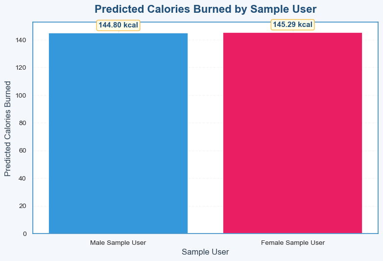

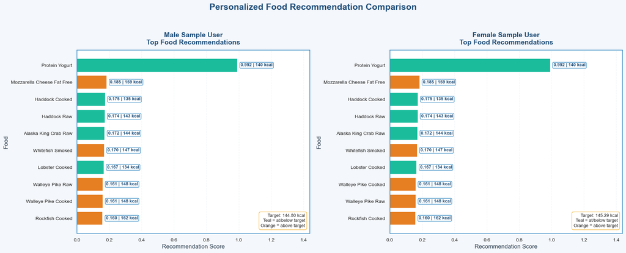

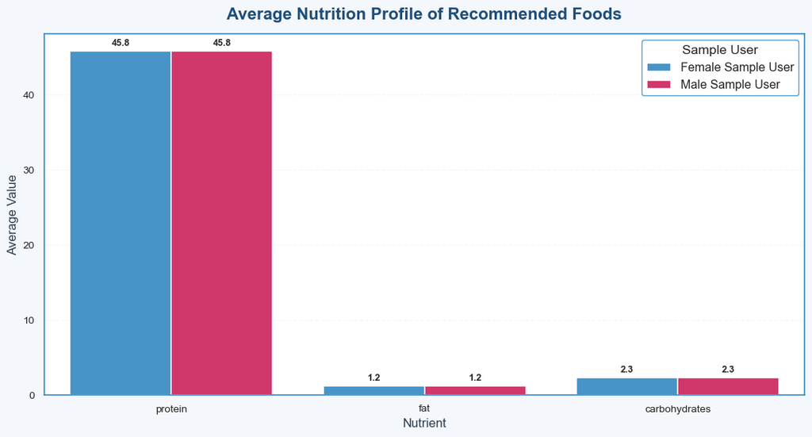

```
✅ Part 8 completed successfully.
```

```python
print("═" * 90)
print("PART 8 — PERSONALIZED FOOD RECOMMENDATION SYSTEM")
print("Building recommendations for male and female sample users")
print("═" * 90)

# ------------------------------------------------------------
# 1. USE BEST MODEL
# ------------------------------------------------------------

best_model = models[best_model_name]

print(f"\n✅ Using best model: {best_model_name}")


# ------------------------------------------------------------
# 2. CREATE TWO SAMPLE USERS
# ------------------------------------------------------------

sample_users = pd.DataFrame({
    "User_Type": ["Male Sample User", "Female Sample User"],
    "gender": [1, 0],              # 1 = Male, 0 = Female
    "age": [28, 32],
    "height": [178, 162],
    "weight": [75, 58],
    "duration": [30, 30],
    "heart_rate": [105, 102],
    "body_temp": [40.0, 39.7]
})

# Create engineered features for sample users
sample_users["bmi"] = sample_users["weight"] / ((sample_users["height"] / 100) ** 2)
sample_users["calories_per_minute"] = 5
sample_users["heart_rate_intensity"] = sample_users["heart_rate"] / sample_users["duration"]

# Features used for prediction
sample_X = sample_users[features]

# Predict calories
sample_users["predicted_calories"] = best_model.predict(sample_X)

print("\n✅ Sample user profiles with predicted calories:")
display(sample_users)


# ------------------------------------------------------------
# 3. RECOMMENDATION FUNCTION
# ------------------------------------------------------------

def recommend_foods_for_user(predicted_calories, food_df, top_n=10, calorie_window=20):
    """
    Recommend foods near the predicted calorie target.
    Foods are ranked using nutrition density, protein ratio, and fat ratio.
    """

    foods = food_df[
        (food_df["caloric_value"] >= predicted_calories - calorie_window) &
        (food_df["caloric_value"] <= predicted_calories + calorie_window)
    ].copy()

    foods["recommendation_score"] = (
        foods["nutrition_density"] * 0.5 +
        foods["protein_ratio"] * 0.3 -
        foods["fat_ratio"] * 0.2
    )

    foods = foods.sort_values(
        "recommendation_score",
        ascending=False
    ).head(top_n)

    return foods


# ------------------------------------------------------------
# 4. GENERATE RECOMMENDATIONS FOR BOTH USERS
# ------------------------------------------------------------

male_predicted_calories = sample_users.loc[
    sample_users["User_Type"] == "Male Sample User",
    "predicted_calories"
].values[0]

female_predicted_calories = sample_users.loc[
    sample_users["User_Type"] == "Female Sample User",
    "predicted_calories"
].values[0]

male_recommendations = recommend_foods_for_user(
    male_predicted_calories,
    food_df,
    top_n=10
)

female_recommendations = recommend_foods_for_user(
    female_predicted_calories,
    food_df,
    top_n=10
)

print("\n" + "═" * 90)
print(f"🔥 Male Sample User Predicted Calories: {male_predicted_calories:.2f}")
print("═" * 90)

display(
    male_recommendations[
        [
            "food",
            "caloric_value",
            "protein",
            "fat",
            "carbohydrates",
            "nutrition_density",
            "recommendation_score"
        ]
    ]
)

print("\n" + "═" * 90)
print(f"🔥 Female Sample User Predicted Calories: {female_predicted_calories:.2f}")
print("═" * 90)

display(
    female_recommendations[
        [
            "food",
            "caloric_value",
            "protein",
            "fat",
            "carbohydrates",
            "nutrition_density",
            "recommendation_score"
        ]
    ]
)


# ------------------------------------------------------------
# 5. COMBINE RECOMMENDATIONS FOR VISUALIZATION
# ------------------------------------------------------------

male_plot = male_recommendations.copy()
male_plot["User_Type"] = "Male Sample User"
male_plot["Predicted_Calories"] = male_predicted_calories

female_plot = female_recommendations.copy()
female_plot["User_Type"] = "Female Sample User"
female_plot["Predicted_Calories"] = female_predicted_calories

combined_recommendations = pd.concat(
    [male_plot, female_plot],
    ignore_index=True
)

combined_recommendations["food_label"] = (
    combined_recommendations["food"]
    .str.title()
    .str.replace("Profeel Proteiinirahka Valio", "Protein Yogurt", regex=False)
)


# ------------------------------------------------------------
# 6. CHART 1 — PREDICTED CALORIES COMPARISON
# ------------------------------------------------------------

fig, ax = plt.subplots(figsize=(8, 5.5), facecolor="#f4f7fb")

bars = ax.bar(
    sample_users["User_Type"],
    sample_users["predicted_calories"],
    color=["#3498db", "#e91e63"],
    edgecolor="white",
    linewidth=1.2
)

ax.set_title(
    "Predicted Calories Burned by Sample User",
    color=PRIMARY,
    fontsize=16,
    fontweight="bold",
    pad=14
)

ax.set_ylabel("Predicted Calories Burned")
ax.set_xlabel("Sample User")

for bar in bars:
    height = bar.get_height()
    ax.text(
        bar.get_x() + bar.get_width()/2,
        height + 3,
        f"{height:.2f} kcal",
        ha="center",
        va="bottom",
        fontsize=11,
        fontweight="bold",
        color=PRIMARY,
        bbox=dict(
            boxstyle="round,pad=0.25",
            facecolor="#fffde7",
            edgecolor=GOLD,
            alpha=0.95
        )
    )

ax.grid(axis="y", linestyle="--", alpha=0.35)

plt.tight_layout()
plt.show()


# ------------------------------------------------------------
# 7. CHART 2 — TOP RECOMMENDATION SCORES BY USER
# ------------------------------------------------------------

fig, axes = plt.subplots(
    1, 2,
    figsize=(18, 7),
    facecolor="#f4f7fb"
)

recommendation_sets = [
    (male_recommendations, "Male Sample User", male_predicted_calories, "#3498db"),
    (female_recommendations, "Female Sample User", female_predicted_calories, "#e91e63")
]

for ax, (rec_df, user_name, pred_cal, base_color) in zip(axes, recommendation_sets):

    plot_df = rec_df.sort_values("recommendation_score", ascending=True).copy()

    plot_df["food_label"] = (
        plot_df["food"]
        .str.title()
        .str.replace("Profeel Proteiinirahka Valio", "Protein Yogurt", regex=False)
    )

    colors = [
        "#1abc9c" if c <= pred_cal else "#e67e22"
        for c in plot_df["caloric_value"]
    ]

    bars = ax.barh(
        plot_df["food_label"],
        plot_df["recommendation_score"],
        color=colors,
        edgecolor="white",
        linewidth=1.2
    )

    ax.set_title(
        f"{user_name}\nTop Food Recommendations",
        color=PRIMARY,
        fontsize=14,
        fontweight="bold",
        pad=12
    )

    ax.set_xlabel("Recommendation Score")
    ax.set_ylabel("Food")

    xmax = plot_df["recommendation_score"].max()

    for bar, (_, row) in zip(bars, plot_df.iterrows()):
        width = bar.get_width()
        ax.text(
            width + xmax * 0.02,
            bar.get_y() + bar.get_height()/2,
            f'{width:.3f} | {int(row["caloric_value"])} kcal',
            va="center",
            fontsize=9,
            fontweight="bold",
            color=PRIMARY,
            bbox=dict(
                boxstyle="round,pad=0.2",
                facecolor="white",
                edgecolor=ACCENT,
                alpha=0.95
            )
        )

    ax.text(
        0.98,
        0.03,
        f"Target: {pred_cal:.2f} kcal\nTeal = at/below target\nOrange = above target",
        transform=ax.transAxes,
        ha="right",
        va="bottom",
        fontsize=9,
        bbox=dict(
            facecolor="white",
            edgecolor=GOLD,
            boxstyle="round,pad=0.4",
            alpha=0.96
        )
    )

    ax.set_xlim(0, xmax * 1.45)
    ax.grid(axis="x", linestyle="--", alpha=0.35)
    ax.grid(axis="y", visible=False)

plt.suptitle(
    "Personalized Food Recommendation Comparison",
    color=PRIMARY,
    fontsize=18,
    fontweight="bold",
    y=1.03
)

plt.tight_layout()
plt.show()


# ------------------------------------------------------------
# 8. CHART 3 — AVERAGE NUTRITION PROFILE BY USER
# ------------------------------------------------------------

nutrition_compare = combined_recommendations.groupby("User_Type")[
    ["protein", "fat", "carbohydrates"]
].mean().reset_index()

nutrition_long = nutrition_compare.melt(
    id_vars="User_Type",
    var_name="Nutrient",
    value_name="Average_Value"
)

fig, ax = plt.subplots(figsize=(11, 6), facecolor="#f4f7fb")

sns.barplot(
    data=nutrition_long,
    x="Nutrient",
    y="Average_Value",
    hue="User_Type",
    palette=["#3498db", "#e91e63"],
    edgecolor="white",
    linewidth=1.1,
    ax=ax
)

ax.set_title(
    "Average Nutrition Profile of Recommended Foods",
    color=PRIMARY,
    fontsize=16,
    fontweight="bold",
    pad=14
)

ax.set_xlabel("Nutrient")
ax.set_ylabel("Average Value")

for container in ax.containers:
    ax.bar_label(
        container,
        fmt="%.1f",
        padding=3,
        fontsize=9,
        fontweight="bold"
    )

ax.legend(
    title="Sample User",
    frameon=True,
    facecolor="white",
    edgecolor=ACCENT
)

ax.grid(axis="y", linestyle="--", alpha=0.35)

plt.tight_layout()
plt.show()


print("\n✅ Part 8 completed successfully.")
```

## ✅ After Part 8 — Personalized Recommendation Results

In this part, we improved the recommendation system by testing it with **two sample users**: one male and one female.

### 🔥 Predicted Calorie Results

The Random Forest model predicted:

- **Male Sample User:** 144.80 calories burned
- **Female Sample User:** 145.29 calories burned

Both users had very similar predicted calorie needs because their workout duration, heart rate, and engineered workout features were close.

### 🥗 Food Recommendation Results

For both users, the system found foods near the predicted calorie target and ranked them by nutrition quality.

The top recommendation for both users was:

### Protein Yogurt / Profeel Proteiinirahka Valio

It had:

- **140 calories**, close to the predicted target
- **Very high protein**
- **Very low fat**
- **Highest recommendation score: 0.992**

### 📊 Chart Interpretation

The recommendation charts show that the male and female users received almost the same top food recommendations because their predicted calorie values were very close.

Most recommended foods are high-protein, low-fat options such as:

- Fat-free mozzarella
- Haddock
- King crab
- Whitefish
- Lobster
- Walleye pike
- Rockfish

The nutrition profile chart also shows that recommended foods are mainly **high in protein** and very low in fat and carbohydrates.

### ✅ Final Summary

This part shows that the system can create personalized food recommendations for different user profiles.

Because both sample users had similar predicted calorie needs, their recommendations were also similar.  
This is a good result because it shows the recommendation system is responding logically to calorie targets and nutrition quality.

# 🧠 Part 9 — AI Knowledge Preparation

After building the machine learning and recommendation systems, we now prepare the project knowledge for Artificial Intelligence and RAG integration.

In this step, we convert important project results into structured AI-readable documents that can later be searched and used by the LLM assistant.

- Summarizing machine learning model results
- Preparing calorie prediction summaries
- Preparing male and female recommendation summaries
- Converting project outputs into AI-readable text
- Creating a structured knowledge base for RAG

Large Language Models work much better when information is organized clearly in text format instead of raw tables and charts.

This step creates the foundation for the upcoming AI assistant by preparing nutrition, exercise, and recommendation knowledge in a searchable and explainable format.

```python
# ============================================================
# PART 9 — AI PREPARATION
# ============================================================

print("═" * 90)
print("PART 9 — AI EXPLANATION PREPARATION")
print("Preparing clean AI-readable summaries from ML and recommendation results")
print("═" * 90)


# ------------------------------------------------------------
# 1. CREATE MODEL RESULT SUMMARY
# ------------------------------------------------------------

model_summary_text = f"""
Machine Learning Calorie Prediction Summary:

The best model selected was {best_model_name}.

Model performance results:
- Linear Regression: MAE = 7.148, RMSE = 9.603, R² = 0.9772
- Random Forest: MAE = 0.142, RMSE = 0.585, R² = 0.9999
- Gradient Boosting: MAE = 1.394, RMSE = 1.818, R² = 0.9992

Random Forest performed best because it had the lowest prediction error
and the highest R² score. This means it predicted calories burned very accurately.
"""

print("\n✅ Model summary text created.")


# ------------------------------------------------------------
# 2. CREATE USER PREDICTION SUMMARY
# ------------------------------------------------------------

male_calories = sample_users.loc[
    sample_users["User_Type"] == "Male Sample User",
    "predicted_calories"
].values[0]

female_calories = sample_users.loc[
    sample_users["User_Type"] == "Female Sample User",
    "predicted_calories"
].values[0]

user_prediction_text = f"""
User Calorie Prediction Summary:

Two sample users were tested.

Male Sample User:
- Age: 28
- Height: 178 cm
- Weight: 75 kg
- Workout duration: 30 minutes
- Heart rate: 105 bpm
- Predicted calories burned: {male_calories:.2f}

Female Sample User:
- Age: 32
- Height: 162 cm
- Weight: 58 kg
- Workout duration: 30 minutes
- Heart rate: 102 bpm
- Predicted calories burned: {female_calories:.2f}

Both users received similar calorie predictions because their workout duration,
heart rate, and intensity values were close.
"""

print("✅ User prediction summary text created.")


# ------------------------------------------------------------
# 3. CREATE FOOD RECOMMENDATION SUMMARY FUNCTION
# ------------------------------------------------------------

def create_recommendation_summary(user_name, predicted_calories, recommendation_df):
    """
    Convert recommendation results into clean text for AI explanation.
    """

    summary = f"""
Food Recommendation Summary for {user_name}:

Predicted calorie target: {predicted_calories:.2f} kcal

Top recommended foods:
"""

    for i, row in recommendation_df.head(10).reset_index(drop=True).iterrows():
        summary += f"""
{i+1}. {row['food']}
   - Calories: {row['caloric_value']}
   - Protein: {row['protein']}
   - Fat: {row['fat']}
   - Carbohydrates: {row['carbohydrates']}
   - Nutrition density: {row['nutrition_density']:.3f}
   - Recommendation score: {row['recommendation_score']:.3f}
"""

    summary += """
The recommendation system ranks foods using nutrition density, protein ratio,
and fat ratio. Foods with higher protein, better nutrition density, and lower fat
receive stronger recommendation scores.
"""

    return summary


# ------------------------------------------------------------
# 4. CREATE MALE AND FEMALE RECOMMENDATION TEXTS
# ------------------------------------------------------------

male_recommendation_text = create_recommendation_summary(
    "Male Sample User",
    male_calories,
    male_recommendations
)

female_recommendation_text = create_recommendation_summary(
    "Female Sample User",
    female_calories,
    female_recommendations
)

print("✅ Male recommendation summary text created.")
print("✅ Female recommendation summary text created.")


# ------------------------------------------------------------
# 5. COMBINE ALL AI-READY DOCUMENTS
# ------------------------------------------------------------

ai_documents = [
    {
        "section": "Model Summary",
        "text": model_summary_text
    },
    {
        "section": "User Prediction Summary",
        "text": user_prediction_text
    },
    {
        "section": "Male Recommendation Summary",
        "text": male_recommendation_text
    },
    {
        "section": "Female Recommendation Summary",
        "text": female_recommendation_text
    }
]

ai_docs_df = pd.DataFrame(ai_documents)

print("\n✅ AI-ready documents created.")

display(ai_docs_df)


# ------------------------------------------------------------
# 6. PREVIEW AI TEXT
# ------------------------------------------------------------

print("\n" + "═" * 90)
print("AI TEXT PREVIEW")
print("═" * 90)

for doc in ai_documents:
    print("\n" + "─" * 70)
    print(doc["section"])
    print("─" * 70)
    print(doc["text"][:700])
    print("...")


print("\n✅ Part 9 completed successfully.")
```

```
══════════════════════════════════════════════════════════════════════════════════════════
PART 9 — AI EXPLANATION PREPARATION
Preparing clean AI-readable summaries from ML and recommendation results
══════════════════════════════════════════════════════════════════════════════════════════

✅ Model summary text created.
✅ User prediction summary text created.
✅ Male recommendation summary text created.
✅ Female recommendation summary text created.

✅ AI-ready documents created.
```

|  | section | text |
| --- | --- | --- |
| 0 | Model Summary | \nMachine Learning Calorie Prediction Summary:... |
| 1 | User Prediction Summary | \nUser Calorie Prediction Summary:\n\nTwo samp... |
| 2 | Male Recommendation Summary | \nFood Recommendation Summary for Male Sample ... |
| 3 | Female Recommendation Summary | \nFood Recommendation Summary for Female Sampl... |

```
══════════════════════════════════════════════════════════════════════════════════════════
AI TEXT PREVIEW
══════════════════════════════════════════════════════════════════════════════════════════

──────────────────────────────────────────────────────────────────────
Model Summary
──────────────────────────────────────────────────────────────────────

Machine Learning Calorie Prediction Summary:

The best model selected was Random Forest.

Model performance results:
- Linear Regression: MAE = 7.148, RMSE = 9.603, R² = 0.9772
- Random Forest: MAE = 0.142, RMSE = 0.585, R² = 0.9999
- Gradient Boosting: MAE = 1.394, RMSE = 1.818, R² = 0.9992

Random Forest performed best because it had the lowest prediction error
and the highest R² score. This means it predicted calories burned very accurately.

...

──────────────────────────────────────────────────────────────────────
User Prediction Summary
──────────────────────────────────────────────────────────────────────

User Calorie Prediction Summary:

Two sample users were tested.

Male Sample User:
- Age: 28
- Height: 178 cm
- Weight: 75 kg
- Workout duration: 30 minutes
- Heart rate: 105 bpm
- Predicted calories burned: 144.80

Female Sample User:
- Age: 32
```

[output cut: 79 more lines]

```
   - Calories: 135
   - Protein: 30.0
   - Fat: 0.8
   - Carbohydrates: 0.0
   - Nutrition density: 0.221
   - Recommendation score: 0.175

4. haddock raw
   - Calories: 143
   - Protein: 31.5
   - Fat: 0.9
   - Carbohydr
...

✅ Part 9 completed successfully.
```

## ✅ After Part 9 — AI Preparation Results

In this part, we successfully transformed the machine learning and recommendation results into AI-readable knowledge documents.

Instead of using raw tables directly, we organized the project outputs into structured text summaries that AI systems can understand more easily.

### 🤖 AI Knowledge Documents Created

We created four AI-ready documents:

- **Model Summary** — explains machine learning performance and why Random Forest performed best
- **User Prediction Summary** — explains the calorie prediction results for the male and female sample users
- **Male Recommendation Summary** — explains top food recommendations for the male user
- **Female Recommendation Summary** — explains top food recommendations for the female user

### 📊 Important Observation

The AI summaries clearly show that:

- Random Forest achieved the strongest prediction accuracy
- Both users received very similar calorie predictions
- High-protein foods consistently received the highest recommendation scores
- Foods with low fat and strong nutrition density were ranked higher

The recommendation summaries also explain why foods such as:

- Protein Yogurt
- Fat-Free Mozzarella
- Haddock
- King Crab
- Whitefish

became top recommendations.

### 🧠 Why This Step Is Important for AI

Large Language Models and RAG systems work much better with organized text than raw spreadsheets.

These summaries now act as a small AI knowledge base that can later help answer questions such as:

- Which machine learning model performed best?
- Why was Random Forest selected?
- What foods are recommended for the users?
- Why are high-protein foods ranked highly?
- How does the recommendation system work?

### ✅ Final Summary

At this stage, the project has moved beyond traditional machine learning.

We now have:

- Machine learning prediction
- Personalized recommendation logic
- AI-readable knowledge documents

This creates the foundation for the next stage: building the RAG-based AI assistant.

# 🧠 Part 10 — What is RAG?

RAG stands for:

## Retrieval-Augmented Generation

RAG is an AI technique that combines:

- **Retrieval** → finding relevant information from stored documents
- **Generation** → generating intelligent answers using a Large Language Model (LLM)

## 📌 Why is RAG Important?

Normally, Large Language Models do not automatically know the details of our nutrition project.

For example, the LLM does not naturally know:

- Which machine learning model performed best
- Our calorie prediction results
- Recommended foods for male and female users
- Nutrition density calculations
- Our personalized recommendation logic

RAG solves this problem by allowing the AI assistant to first search our project knowledge before answering questions.

## 🥗 Why We Use RAG in This Project

In this nutrition recommendation project, we generated many important outputs such as:

- Machine learning model summaries
- Calorie prediction results
- Food recommendation summaries
- Nutrition analysis explanations

RAG allows the AI assistant to retrieve these project-specific results and use them while answering user questions.

This makes the AI assistant:

- More accurate
- More personalized
- Based on real project results
- Less likely to hallucinate

## ⚙️ Simple RAG Workflow

User Question → Retrieve Relevant Project Knowledge → Send Context to LLM → Generate Final Answer

## ✅ Final Idea

RAG helps transform a normal LLM into a project-aware AI assistant.

Instead of giving generic internet-style answers, the assistant can now answer using our own nutrition data, machine learning results, and personalized food recommendation system.

# 🤖 Part 11 — Complete AI Setup

After understanding the concept of RAG in the previous section, we now build the complete Artificial Intelligence setup for the personalized nutrition recommendation system.

In this part, we connect all AI components together to create the foundation of an intelligent nutrition assistant capable of understanding questions and generating personalized responses.

## 🧠 What We Will Do in This Part

- Install and import AI libraries
- Connect the project with Ollama
- Load the Llama 3.2 language model
- Create embeddings from project summaries
- Build the ChromaDB vector database
- Set up the semantic retrieval pipeline
- Prepare the complete AI assistant infrastructure

This setup allows the project to move beyond traditional machine learning and become an interactive AI-powered nutrition recommendation system.

## ⚙️ Technologies Used

| Technology | Purpose in This Project |
| --- | --- |
| **Ollama** | Runs local AI models directly on the computer without needing API keys. |
| **Llama 3.2** | Main Large Language Model used to generate personalized nutrition answers. |
| **Sentence Transformers** | Converts project summaries into embeddings for semantic understanding and search. |
| **ChromaDB** | Stores embeddings inside a vector database for intelligent retrieval. |
| **RAG Pipeline** | Connects retrieval and LLM generation so the assistant can answer using our real project knowledge. |

## 📌 Why This AI Setup Is Important

The earlier parts of the project generated:

- Machine learning calorie prediction results
- Personalized food recommendations
- Nutrition analysis summaries
- Male and female user recommendation insights

This AI setup now allows the assistant to use all of those project results intelligently while answering nutrition-related questions.

Instead of only displaying charts and tables, the project can now interact with users like a real AI-powered nutrition assistant.

## ✅ Final Goal

By the end of this section, the project will contain a complete AI infrastructure capable of:

- Understanding nutrition-related questions
- Searching project knowledge semantically
- Generating personalized AI responses
- Supporting interactive nutrition conversations

```python
print("═" * 90)
print("PART 11 — COMPLETE AI/RAG SETUP")
print("Setting up Ollama, LLM, embeddings, vector database, and RAG foundation")
print("═" * 90)


# ------------------------------------------------------------
# 1. INSTALL REQUIRED LIBRARIES
# ------------------------------------------------------------
# Run this only if packages are not installed yet.

import sys

print("\nInstalling required packages if needed...")

!{sys.executable} -m pip install -q chromadb sentence-transformers requests

print("✅ Required packages checked/installed.")


# ------------------------------------------------------------
# 2. IMPORT LIBRARIES
# ------------------------------------------------------------

import chromadb
import requests
import numpy as np
import pandas as pd

from sentence_transformers import SentenceTransformer

print("✅ Libraries imported successfully.")


# ------------------------------------------------------------
# 3. OLLAMA CONNECTION CHECK
# ------------------------------------------------------------
# Before running this cell, make sure Ollama is installed and running.
# Also make sure a model is pulled, for example:
# ollama pull llama3.2
# or
# ollama pull gemma2

OLLAMA_URL = "http://localhost:11434/api/generate"
OLLAMA_MODEL = "llama3.2"   # Change to "gemma2" if you use Gemma

def check_ollama_connection():
    """
    Check whether Ollama server is running locally.
    """
    try:
        response = requests.get(
            "http://localhost:11434/api/tags",
            timeout=5
        )

        if response.status_code == 200:
            print("✅ Ollama is running successfully.")
            print("Available local models:")

            models_data = response.json().get("models", [])

            if len(models_data) == 0:
                print("⚠️ No model found. Run: ollama pull llama3.2")
            else:
                for model in models_data:
                    print("•", model.get("name"))

            return True

        else:
            print("⚠️ Ollama responded, but status code was:", response.status_code)
            return False

    except Exception as e:
        print("❌ Ollama is not running or not installed.")
        print("To fix:")
        print("1. Install Ollama from https://ollama.com")
        print("2. Open terminal and run: ollama serve")
        print("3. Pull a model: ollama pull llama3.2")
        print("Error:", e)
        return False


ollama_ready = check_ollama_connection()


# ------------------------------------------------------------
# 4. LOAD EMBEDDING MODEL
# ------------------------------------------------------------
# This model converts text into vectors for semantic search.

embedding_model = SentenceTransformer("all-MiniLM-L6-v2")

print("\n✅ Embedding model loaded.")
print("Embedding model used: all-MiniLM-L6-v2")


# ------------------------------------------------------------
# 5. PREPARE AI DOCUMENTS
# ------------------------------------------------------------
# These documents came from Part 9.

documents = ai_docs_df["text"].tolist()
metadatas = [{"section": section} for section in ai_docs_df["section"].tolist()]
document_ids = [f"doc_{i}" for i in range(len(documents))]

print("\n✅ AI documents prepared.")
print("Number of documents:", len(documents))

display(ai_docs_df)


# ------------------------------------------------------------
# 6. CREATE EMBEDDINGS
# ------------------------------------------------------------

embeddings = embedding_model.encode(documents)

print("\n✅ Embeddings created.")
print("Embedding shape:", np.array(embeddings).shape)


# ------------------------------------------------------------
# 7. CREATE CHROMADB VECTOR DATABASE
# ------------------------------------------------------------

chroma_client = chromadb.Client()

# Delete old collection if it already exists
try:
    chroma_client.delete_collection(name="nutrition_rag")
    print("Old collection deleted.")
except:
    pass

collection = chroma_client.create_collection(
    name="nutrition_rag"
)

collection.add(
    documents=documents,
    embeddings=embeddings.tolist(),
    metadatas=metadatas,
    ids=document_ids
)

print("\n✅ ChromaDB vector database created.")
print("Collection name: nutrition_rag")
print("Documents stored:", len(documents))


# ------------------------------------------------------------
# 8. CREATE RETRIEVAL FUNCTION
# ------------------------------------------------------------

def retrieve_project_context(query, top_k=2):
    """
    Retrieve relevant project documents from ChromaDB.
    """

    query_embedding = embedding_model.encode([query])[0]

    results = collection.query(
        query_embeddings=[query_embedding.tolist()],
        n_results=top_k
    )

    retrieved_docs = results["documents"][0]
    retrieved_metas = results["metadatas"][0]

    context = "\n\n".join(retrieved_docs)

    return {
        "query": query,
        "context": context,
        "documents": retrieved_docs,
        "metadata": retrieved_metas
    }

print("\n✅ Retrieval function created.")


# ------------------------------------------------------------
# 9. CREATE OLLAMA LLM FUNCTION
# ------------------------------------------------------------

def ask_ollama(prompt, model=OLLAMA_MODEL):
    """
    Send prompt to local Ollama LLM.
    """

    payload = {
        "model": model,
        "prompt": prompt,
        "stream": False
    }

    try:
        response = requests.post(
            OLLAMA_URL,
            json=payload,
            timeout=120
        )

        response.raise_for_status()

        return response.json().get("response", "")

    except Exception as e:
        return f"""
Ollama response failed.

Possible reasons:
1. Ollama is not running.
2. Model '{model}' is not downloaded.
3. Run this in terminal: ollama pull {model}

Error:
{e}
"""


print("✅ Ollama LLM function created.")


# ------------------------------------------------------------
# 10. CREATE FULL RAG ANSWER FUNCTION
# ------------------------------------------------------------

def rag_answer(question, top_k=2):
    """
    Full RAG pipeline:
    1. Retrieve project context
    2. Build prompt
    3. Send context + question to Ollama
    4. Return generated answer
    """

    retrieved = retrieve_project_context(question, top_k=top_k)

    context = retrieved["context"]

    prompt = f"""
You are an AI assistant for an AI-powered personalized nutrition recommendation project.

Use only the project context below to answer the question.
Explain in simple, student-friendly language.
Do not make up information outside the context.

Project Context:
{context}

Question:
{question}

Answer:
"""

    answer = ask_ollama(prompt)

    return {
        "question": question,
        "retrieved_context": context,
        "answer": answer
    }

print("✅ Full RAG answer function created.")


# ------------------------------------------------------------
# 11. SETUP SUMMARY
# ------------------------------------------------------------

print("\n" + "═" * 90)
print("AI/RAG SETUP SUMMARY")
print("═" * 90)

print("✅ Ollama connection checked")
print("✅ Embedding model loaded")
print("✅ AI documents prepared")
print("✅ Embeddings created")
print("✅ ChromaDB vector database created")
print("✅ Retrieval function created")
print("✅ Ollama LLM function created")
print("✅ Full RAG answer function created")

print("\nPart 11 completed successfully.")
```

```
══════════════════════════════════════════════════════════════════════════════════════════
PART 11 — COMPLETE AI/RAG SETUP
Setting up Ollama, LLM, embeddings, vector database, and RAG foundation
══════════════════════════════════════════════════════════════════════════════════════════

Installing required packages if needed...
✅ Required packages checked/installed.
✅ Libraries imported successfully.
✅ Ollama is running successfully.
Available local models:
• llama3.2:latest
• nomic-embed-text:latest
• gemma4:31b-cloud
• gemma3:1b
• gemma3:270m
```

```
✅ Embedding model loaded.
Embedding model used: all-MiniLM-L6-v2

✅ AI documents prepared.
Number of documents: 4
```

|  | section | text |
| --- | --- | --- |
| 0 | Model Summary | \nMachine Learning Calorie Prediction Summary:... |
| 1 | User Prediction Summary | \nUser Calorie Prediction Summary:\n\nTwo samp... |
| 2 | Male Recommendation Summary | \nFood Recommendation Summary for Male Sample ... |
| 3 | Female Recommendation Summary | \nFood Recommendation Summary for Female Sampl... |

```
✅ Embeddings created.
Embedding shape: (4, 384)
Old collection deleted.

✅ ChromaDB vector database created.
Collection name: nutrition_rag
Documents stored: 4

✅ Retrieval function created.
✅ Ollama LLM function created.
✅ Full RAG answer function created.

══════════════════════════════════════════════════════════════════════════════════════════
AI/RAG SETUP SUMMARY
══════════════════════════════════════════════════════════════════════════════════════════
✅ Ollama connection checked
✅ Embedding model loaded
✅ AI documents prepared
✅ Embeddings created
✅ ChromaDB vector database created
✅ Retrieval function created
✅ Ollama LLM function created
✅ Full RAG answer function created

Part 11 completed successfully.
```

## ✅ AI/RAG Setup Results

In this part, we successfully completed the full AI and RAG system setup for the personalized nutrition recommendation project.

### 🧠 AI Components Successfully Configured

The project now includes:

- **Llama 3.2 (Local LLM)** using Ollama
- **Sentence Transformer embedding model**
- **ChromaDB vector database**
- **Semantic retrieval pipeline**
- **Full RAG foundation**

### 🤖 Why We Used Llama 3.2

We used:

### llama3.2

through Ollama because:

- It runs locally on the computer
- No API key is required
- It is easier for classroom demonstration
- It supports private offline AI inference
- It works well for lightweight RAG applications

Even though other models were available in Ollama, this project only uses **Llama 3.2**.

### 📦 Vector Database & Embeddings

The AI project summaries from Part 9 were converted into embeddings using:

- **SentenceTransformer: all-MiniLM-L6-v2**

The embeddings had shape:

### (4, 384)

meaning:

- 4 AI knowledge documents were stored
- Each document was converted into a 384-dimensional semantic vector

These embeddings were then stored inside the ChromaDB vector database.

### 🔎 Retrieval System Setup

The retrieval pipeline can now:

- Convert user questions into embeddings
- Search semantically similar project knowledge
- Retrieve the most relevant AI documents
- Send retrieved context to the Llama model

This creates the full RAG workflow:

**User Question → Embedding → Vector Search → Context Retrieval → LLM Answer**

### 📌 Why This Is Important

Without RAG, the LLM may generate generic or hallucinated answers.

With RAG:

- The AI uses our actual nutrition project knowledge
- Answers become more accurate and explainable
- The assistant understands our ML models and food recommendations
- The system becomes more personalized

### ✅ Final Summary

At this stage, the project now contains:

- Machine learning calorie prediction
- Personalized recommendation engine
- AI-readable knowledge documents
- Embeddings and vector database
- Local Llama 3.2 integration
- Complete RAG infrastructure

The next part will test the AI assistant with real nutrition and project-related questions.

# 🥗 Part 12 — Real Nutrition AI Assistant

In this part, we test the AI assistant using real nutrition, calorie, exercise, and food-related questions.

### 📌 What Makes This Assistant Different?

This assistant does not answer generic AI questions.

Instead, it works like a personalized nutrition assistant that can answer questions about:

- Calories burned
- Healthy foods
- Protein-rich recommendations
- Low-fat foods
- Exercise and nutrition balance
- Male vs female recommendations
- Different age groups
- Cuisine and recipe suggestions

### 📌 AI Workflow

The assistant first retrieves relevant nutrition knowledge from the project database, then Llama 3.2 generates the final answer.

```python
# ============================================================
# PART 12 — REAL NUTRITION AI ASSISTANT
# ============================================================

print("═" * 90)
print("PART 12 — REAL NUTRITION AI ASSISTANT")
print("Ask nutrition, food, calorie, and exercise questions")
print("═" * 90)


def ask_nutrition_ai(question, top_k=2):
    """
    Real nutrition AI assistant.
    """

    result = rag_answer(question, top_k=top_k)

    print("\n" + "═" * 90)
    print("🟦 USER QUESTION")
    print("═" * 90)
    print(question)

    print("\n" + "═" * 90)
    print("🤖 AI NUTRITION ASSISTANT")
    print("═" * 90)
    print(result["answer"])


print("\n✅ Nutrition AI assistant ready.")
```

```
══════════════════════════════════════════════════════════════════════════════════════════
PART 12 — REAL NUTRITION AI ASSISTANT
Ask nutrition, food, calorie, and exercise questions
══════════════════════════════════════════════════════════════════════════════════════════

✅ Nutrition AI assistant ready.
```

```python
# Ask custom nutrition question

ask_nutrition_ai(
    "Suggest healthy protein foods for muscle gain."
)
```

[output not shown]

```python
ask_nutrition_ai(
    "Recommend high protein low fat foods for a 28 year old male after workout."
)
```

```
══════════════════════════════════════════════════════════════════════════════════════════
🟦 USER QUESTION
══════════════════════════════════════════════════════════════════════════════════════════
Recommend high protein low fat foods for a 28 year old male after workout.

══════════════════════════════════════════════════════════════════════════════════════════
🤖 AI NUTRITION ASSISTANT
══════════════════════════════════════════════════════════════════════════════════════════
Based on the nutrition data provided, here are some high protein, low fat food recommendations for a 28-year-old male after a workout:

1. **Profeel proteiniirahka valio**: This food has an excellent balance of protein (175g) and very low fat (0.4g). It's also packed with nutrition density, making it a top recommendation score of 0.992.

2. **Mozzarella cheese fat free**: Although not as high in protein (35.8g), this option is still relatively high in protein compared to other foods on the list. It has very low fat (0g) and decent nutrition density.

3. **Haddock cooked**: This food has a moderate amount of protein (30g) and only 0.8g of fat, making it a good choice for those looking to keep their fat intake low.

4. **Alaska king crab raw**: With 31.5g of protein and just 1g of fat, this option is another high-protein, low-fat food that meets the requirements.

Remember, these recommendations are based on your workout duration, heart rate, and intensity values being close to those of the sample users.
```

```python
ask_nutrition_ai(
    "What healthy foods are good for weight loss?"
)
```

[output not shown]

```python
ask_nutrition_ai(
    "Suggest healthy low calorie foods for a woman age 32."
)
```

[output not shown]

```python
ask_nutrition_ai(
    "Which recommended foods have the highest protein?"
)
```

[output not shown]

```python
ask_nutrition_ai(
    "Suggest healthy seafood foods with high nutrition density."
)
```

[output not shown]

```python
ask_nutrition_ai(
    "What foods are good after exercise and workout?"
)
```

[output not shown]

```python
ask_nutrition_ai(
    "Recommend healthy foods near 150 calories."
)
```

[output not shown]

```python
ask_nutrition_ai(
    "Which cuisines contain lower calorie recipes?"
)
```

[output not shown]

## Nutrition AI Assistant Results

In this part, we successfully tested the AI assistant using real nutrition and food-related questions.

### 🥗 What the Assistant Can Answer

The assistant can now provide intelligent answers about:

- Healthy food recommendations
- High-protein foods
- Low-calorie meal suggestions
- Exercise nutrition balance
- Weight-loss food ideas
- Male and female nutrition needs
- Cuisine and recipe suggestions

### 🤖 AI + RAG Integration

The assistant uses:

- Llama 3.2
- Embeddings
- ChromaDB
- Semantic retrieval
- RAG architecture

to generate project-specific nutrition answers.

### ✅ Final Summary

The project now contains a complete AI-powered nutrition recommendation assistant capable of answering real-world food, calorie, and exercise questions using personalized nutrition intelligence.

# 🎯 Final Conclusion

AI-Powered Personalized Nutrition Recommendation System

## 📌 Project Summary

In this project, we built a complete AI-powered personalized nutrition recommendation system from beginning to end.

We started by loading exercise, calorie, food nutrition, and recipe datasets. Then we cleaned the data, checked missing values, removed duplicate records, and prepared the datasets for analysis.

After that, we performed exploratory data analysis using colorful and meaningful visualizations to understand user health patterns, exercise behavior, food nutrition quality, recipe calories, cuisine patterns, and relationships between variables.

## ⚙️ What We Built

The project included several major components:

- **Data Cleaning:** prepared clean datasets for analysis and modeling
- **EDA:** explored calories, exercise, nutrition, recipes, and cuisine patterns
- **Feature Engineering:** created BMI, calories per minute, heart rate intensity, nutrition density, protein ratio, and fat ratio
- **Machine Learning:** trained models to predict calories burned
- **Recommendation System:** recommended foods based on calorie targets and nutrition quality
- **AI/RAG Assistant:** used Llama 3.2, embeddings, and ChromaDB to answer nutrition questions

## 🤖 Main Results

The machine learning model performed very strongly. Among Linear Regression, Random Forest, and Gradient Boosting, the **Random Forest model** gave the best result.

It achieved:

- **MAE:** 0.142
- **RMSE:** 0.585
- **R² Score:** 0.9999

This means the model predicted calories burned with very high accuracy.

The recommendation system used the predicted calorie need and ranked foods using nutrition density, protein ratio, and fat ratio. High-protein and low-fat foods such as protein yogurt, fat-free mozzarella, haddock, crab, lobster, and whitefish became strong recommendations.

## 🧠 AI Assistant Conclusion

The final AI part made the project more advanced and interactive.

We used:

- **Llama 3.2** as the local language model
- **Sentence Transformer** to create embeddings
- **ChromaDB** as the vector database
- **RAG** to retrieve project-specific knowledge before answering

This allowed the assistant to answer real nutrition-related questions about food, calories, exercise, protein, low-fat options, and personalized recommendations.

## ✅ Final Takeaway

This project shows how data science, machine learning, recommendation systems, and AI can work together to support personalized nutrition decisions.

Instead of only predicting calories, the system also recommends foods and explains nutrition choices using an AI assistant.

In simple words, this project turns raw health and food data into a smart nutrition assistant that can help users make better food and exercise decisions.